# Project: Identify Customer Segments

In this project, you will apply unsupervised learning techniques to identify segments of the population that form the core customer base for a mail-order sales company in Germany. These segments can then be used to direct marketing campaigns towards audiences that will have the highest expected rate of returns. The data that you will use has been provided by our partners at Bertelsmann Arvato Analytics, and represents a real-life data science task.

This notebook will help you complete this task by providing a framework within which you will perform your analysis steps. In each step of the project, you will see some text describing the subtask that you will perform, followed by one or more code cells for you to complete your work. **Feel free to add additional code and markdown cells as you go along so that you can explore everything in precise chunks.** The code cells provided in the base template will outline only the major tasks, and will usually not be enough to cover all of the minor tasks that comprise it.

It should be noted that while there will be precise guidelines on how you should handle certain tasks in the project, there will also be places where an exact specification is not provided. **There will be times in the project where you will need to make and justify your own decisions on how to treat the data.** These are places where there may not be only one way to handle the data. In real-life tasks, there may be many valid ways to approach an analysis task. One of the most important things you can do is clearly document your approach so that other scientists can understand the decisions you've made.

At the end of most sections, there will be a Markdown cell labeled **Discussion**. In these cells, you will report your findings for the completed section, as well as document the decisions that you made in your approach to each subtask. **Your project will be evaluated not just on the code used to complete the tasks outlined, but also your communication about your observations and conclusions at each stage.**

```python
# import libraries here; add more as necessary
import numpy as np
import pandas as pd
import matplotlib.pyplot as plt
import seaborn as sns

from sklearn.preprocessing import Imputer, StandardScaler
from sklearn.decomposition import PCA
from sklearn.cluster import KMeans

# magic word for producing visualizations in notebook
%matplotlib inline

'''
Import note: The classroom currently uses sklearn version 0.19.
If you need to use an imputer, it is available in sklearn.preprocessing.Imputer,
instead of sklearn.impute as in newer versions of sklearn.
'''
```

```
'\nImport note: The classroom currently uses sklearn version 0.19.\nIf you need to use an imputer, it is available in sklearn.preprocessing.Imputer,\ninstead of sklearn.impute as in newer versions of sklearn.\n'
```

### Step 0: Load the Data

There are four files associated with this project (not including this one):

Each row of the demographics files represents a single person, but also includes information outside of individuals, including information about their household, building, and neighborhood. You will use this information to cluster the general population into groups with similar demographic properties. Then, you will see how the people in the customers dataset fit into those created clusters. The hope here is that certain clusters are over-represented in the customers data, as compared to the general population; those over-represented clusters will be assumed to be part of the core userbase. This information can then be used for further applications, such as targeting for a marketing campaign.

To start off with, load in the demographics data for the general population into a pandas DataFrame, and do the same for the feature attributes summary. Note for all of the `.csv` data files in this project: they're semicolon (`;`) delimited, so you'll need an additional argument in your [`read_csv()`](https://pandas.pydata.org/pandas-docs/stable/generated/pandas.read_csv.html) call to read in the data properly. Also, considering the size of the main dataset, it may take some time for it to load completely.

Once the dataset is loaded, it's recommended that you take a little bit of time just browsing the general structure of the dataset and feature summary file. You'll be getting deep into the innards of the cleaning in the first major step of the project, so gaining some general familiarity can help you get your bearings.

```python
# Load in the general demographics data.
azdias = pd.read_csv('Udacity_AZDIAS_Subset.csv', delimiter=";")

# Load in the feature summary file.
feat_info = pd.read_csv('AZDIAS_Feature_Summary.csv', delimiter=";")
```

```python
# Check the structure of the data after it's loaded (e.g. print the number of
# rows and columns, print the first few rows).
azdias.head()
```

|  | AGER_TYP | ALTERSKATEGORIE_GROB | ANREDE_KZ | CJT_GESAMTTYP | FINANZ_MINIMALIST | FINANZ_SPARER | FINANZ_VORSORGER | FINANZ_ANLEGER | FINANZ_UNAUFFAELLIGER | FINANZ_HAUSBAUER | ... | PLZ8_ANTG1 | PLZ8_ANTG2 | PLZ8_ANTG3 | PLZ8_ANTG4 | PLZ8_BAUMAX | PLZ8_HHZ | PLZ8_GBZ | ARBEIT | ORTSGR_KLS9 | RELAT_AB |
| --- | --- | --- | --- | --- | --- | --- | --- | --- | --- | --- | --- | --- | --- | --- | --- | --- | --- | --- | --- | --- | --- |
| 0 | -1 | 2 | 1 | 2.0 | 3 | 4 | 3 | 5 | 5 | 3 | ... | NaN | NaN | NaN | NaN | NaN | NaN | NaN | NaN | NaN | NaN |
| 1 | -1 | 1 | 2 | 5.0 | 1 | 5 | 2 | 5 | 4 | 5 | ... | 2.0 | 3.0 | 2.0 | 1.0 | 1.0 | 5.0 | 4.0 | 3.0 | 5.0 | 4.0 |
| 2 | -1 | 3 | 2 | 3.0 | 1 | 4 | 1 | 2 | 3 | 5 | ... | 3.0 | 3.0 | 1.0 | 0.0 | 1.0 | 4.0 | 4.0 | 3.0 | 5.0 | 2.0 |
| 3 | 2 | 4 | 2 | 2.0 | 4 | 2 | 5 | 2 | 1 | 2 | ... | 2.0 | 2.0 | 2.0 | 0.0 | 1.0 | 3.0 | 4.0 | 2.0 | 3.0 | 3.0 |
| 4 | -1 | 3 | 1 | 5.0 | 4 | 3 | 4 | 1 | 3 | 2 | ... | 2.0 | 4.0 | 2.0 | 1.0 | 2.0 | 3.0 | 3.0 | 4.0 | 6.0 | 5.0 |

5 rows × 85 columns

```python
azdias.describe()
```

|  | AGER_TYP | ALTERSKATEGORIE_GROB | ANREDE_KZ | CJT_GESAMTTYP | FINANZ_MINIMALIST | FINANZ_SPARER | FINANZ_VORSORGER | FINANZ_ANLEGER | FINANZ_UNAUFFAELLIGER | FINANZ_HAUSBAUER | ... | PLZ8_ANTG1 | PLZ8_ANTG2 | PLZ8_ANTG3 | PLZ8_ANTG4 | PLZ8_BAUMAX | PLZ8_HHZ | PLZ8_GBZ | ARBEIT | ORTSGR_KLS9 | RELAT_AB |
| --- | --- | --- | --- | --- | --- | --- | --- | --- | --- | --- | --- | --- | --- | --- | --- | --- | --- | --- | --- | --- | --- |
| count | 891221.000000 | 891221.000000 | 891221.000000 | 886367.000000 | 891221.000000 | 891221.000000 | 891221.000000 | 891221.000000 | 891221.000000 | 891221.000000 | ... | 774706.000000 | 774706.000000 | 774706.000000 | 774706.000000 | 774706.000000 | 774706.000000 | 774706.000000 | 794005.000000 | 794005.000000 | 794005.00000 |
| mean | -0.358435 | 2.777398 | 1.522098 | 3.632838 | 3.074528 | 2.821039 | 3.401106 | 3.033328 | 2.874167 | 3.075121 | ... | 2.253330 | 2.801858 | 1.595426 | 0.699166 | 1.943913 | 3.612821 | 3.381087 | 3.167854 | 5.293002 | 3.07222 |
| std | 1.198724 | 1.068775 | 0.499512 | 1.595021 | 1.321055 | 1.464749 | 1.322134 | 1.529603 | 1.486731 | 1.353248 | ... | 0.972008 | 0.920309 | 0.986736 | 0.727137 | 1.459654 | 0.973967 | 1.111598 | 1.002376 | 2.303739 | 1.36298 |
| min | -1.000000 | 1.000000 | 1.000000 | 1.000000 | 1.000000 | 1.000000 | 1.000000 | 1.000000 | 1.000000 | 1.000000 | ... | 0.000000 | 0.000000 | 0.000000 | 0.000000 | 1.000000 | 1.000000 | 1.000000 | 1.000000 | 0.000000 | 1.00000 |
| 25% | -1.000000 | 2.000000 | 1.000000 | 2.000000 | 2.000000 | 1.000000 | 3.000000 | 2.000000 | 2.000000 | 2.000000 | ... | 1.000000 | 2.000000 | 1.000000 | 0.000000 | 1.000000 | 3.000000 | 3.000000 | 3.000000 | 4.000000 | 2.00000 |
| 50% | -1.000000 | 3.000000 | 2.000000 | 4.000000 | 3.000000 | 3.000000 | 3.000000 | 3.000000 | 3.000000 | 3.000000 | ... | 2.000000 | 3.000000 | 2.000000 | 1.000000 | 1.000000 | 4.000000 | 3.000000 | 3.000000 | 5.000000 | 3.00000 |
| 75% | -1.000000 | 4.000000 | 2.000000 | 5.000000 | 4.000000 | 4.000000 | 5.000000 | 5.000000 | 4.000000 | 4.000000 | ... | 3.000000 | 3.000000 | 2.000000 | 1.000000 | 3.000000 | 4.000000 | 4.000000 | 4.000000 | 7.000000 | 4.00000 |
| max | 3.000000 | 9.000000 | 2.000000 | 6.000000 | 5.000000 | 5.000000 | 5.000000 | 5.000000 | 5.000000 | 5.000000 | ... | 4.000000 | 4.000000 | 3.000000 | 2.000000 | 5.000000 | 5.000000 | 5.000000 | 9.000000 | 9.000000 | 9.00000 |

8 rows × 81 columns

```python
azdias.info()
```

```
<class 'pandas.core.frame.DataFrame'>
RangeIndex: 891221 entries, 0 to 891220
Data columns (total 85 columns):
AGER_TYP                 891221 non-null int64
ALTERSKATEGORIE_GROB     891221 non-null int64
ANREDE_KZ                891221 non-null int64
CJT_GESAMTTYP            886367 non-null float64
FINANZ_MINIMALIST        891221 non-null int64
FINANZ_SPARER            891221 non-null int64
FINANZ_VORSORGER         891221 non-null int64
FINANZ_ANLEGER           891221 non-null int64
FINANZ_UNAUFFAELLIGER    891221 non-null int64
FINANZ_HAUSBAUER         891221 non-null int64
FINANZTYP                891221 non-null int64
GEBURTSJAHR              891221 non-null int64
GFK_URLAUBERTYP          886367 non-null float64
GREEN_AVANTGARDE         891221 non-null int64
HEALTH_TYP               891221 non-null int64
LP_LEBENSPHASE_FEIN      886367 non-null float64
LP_LEBENSPHASE_GROB      886367 non-null float64
LP_FAMILIE_FEIN          886367 non-null float64
LP_FAMILIE_GROB          886367 non-null float64
LP_STATUS_FEIN           886367 non-null float64
LP_STATUS_GROB           886367 non-null float64
NATIONALITAET_KZ         891221 non-null int64
PRAEGENDE_JUGENDJAHRE    891221 non-null int64
RETOURTYP_BK_S           886367 non-null float64
SEMIO_SOZ                891221 non-null int64
SEMIO_FAM                891221 non-null int64
SEMIO_REL                891221 non-null int64
SEMIO_MAT                891221 non-null int64
SEMIO_VERT               891221 non-null int64
SEMIO_LUST               891221 non-null int64
SEMIO_ERL                891221 non-null int64
SEMIO_KULT               891221 non-null int64
SEMIO_RAT                891221 non-null int64
SEMIO_KRIT               891221 non-null int64
SEMIO_DOM                891221 non-null int64
SEMIO_KAEM               891221 non-null int64
SEMIO_PFLICHT            891221 non-null int64
```

[output cut: 35 more lines]

```
ONLINE_AFFINITAET        886367 non-null float64
REGIOTYP                 770025 non-null float64
KBA13_ANZAHL_PKW         785421 non-null float64
PLZ8_ANTG1               774706 non-null float64
PLZ8_ANTG2               774706 non-null float64
PLZ8_ANTG3               774706 non-null float64
PLZ8_ANTG4               774706 non-null float64
PLZ8_BAUMAX              774706 non-null float64
PLZ8_HHZ                 774706 non-null float64
PLZ8_GBZ                 774706 non-null float64
ARBEIT                   794005 non-null float64
ORTSGR_KLS9              794005 non-null float64
RELAT_AB                 794005 non-null float64
dtypes: float64(49), int64(32), object(4)
memory usage: 578.0+ MB
```

```python
feat_info.head()
```

|  | attribute | information_level | type | missing_or_unknown |
| --- | --- | --- | --- | --- |
| 0 | AGER_TYP | person | categorical | [-1,0] |
| 1 | ALTERSKATEGORIE_GROB | person | ordinal | [-1,0,9] |
| 2 | ANREDE_KZ | person | categorical | [-1,0] |
| 3 | CJT_GESAMTTYP | person | categorical | [0] |
| 4 | FINANZ_MINIMALIST | person | ordinal | [-1] |

```python
feat_info.describe()
```

|  | attribute | information_level | type | missing_or_unknown |
| --- | --- | --- | --- | --- |
| count | 85 | 85 | 85 | 85 |
| unique | 85 | 9 | 5 | 9 |
| top | PLZ8_HHZ | person | ordinal | [-1] |
| freq | 1 | 43 | 49 | 26 |

```python
feat_info.info()
```

```
<class 'pandas.core.frame.DataFrame'>
RangeIndex: 85 entries, 0 to 84
Data columns (total 4 columns):
attribute             85 non-null object
information_level     85 non-null object
type                  85 non-null object
missing_or_unknown    85 non-null object
dtypes: object(4)
memory usage: 2.7+ KB
```

#### Discussion

The demographic data in the `azdias` dataframe contain 891,221 records and 85 attributes. Several attributes already have existing NaN values as shown by the lower count values in the describe() method. The attributes are of types: int, float, or object.

The feature summary in the `feat_info` dataset contains all 85 features. The `missing_or_unknown` attribute is a list stored as a string object.

> **Tip**: Add additional cells to keep everything in reasonably-sized chunks! Keyboard shortcut `esc --> a` (press escape to enter command mode, then press the 'A' key) adds a new cell before the active cell, and `esc --> b` adds a new cell after the active cell. If you need to convert an active cell to a markdown cell, use `esc --> m` and to convert to a code cell, use `esc --> y`.

## Step 1: Preprocessing

### Step 1.1: Assess Missing Data

The feature summary file contains a summary of properties for each demographics data column. You will use this file to help you make cleaning decisions during this stage of the project. First of all, you should assess the demographics data in terms of missing data. Pay attention to the following points as you perform your analysis, and take notes on what you observe. Make sure that you fill in the **Discussion** cell with your findings and decisions at the end of each step that has one!

#### Step 1.1.1: Convert Missing Value Codes to NaNs

The fourth column of the feature attributes summary (loaded in above as `feat_info`) documents the codes from the data dictionary that indicate missing or unknown data. While the file encodes this as a list (e.g. `[-1,0]`), this will get read in as a string object. You'll need to do a little bit of parsing to make use of it to identify and clean the data. Convert data that matches a 'missing' or 'unknown' value code into a numpy NaN value. You might want to see how much data takes on a 'missing' or 'unknown' code, and how much data is naturally missing, as a point of interest.

**As one more reminder, you are encouraged to add additional cells to break up your analysis into manageable chunks.**

Let's first create a dictonary to replacing the missing or unkown values with NaN, where the keys are attributes and values are a list. We saw before that the `missing_or_unknown` attribute is a list stored as a string object. We will convert the string object to a list. Note that the missing or unknown values are either an integer value or a string of `` `, ``X`, or`XX`, as shown below.

```python
feat_info['missing_or_unknown'].unique()
```

```
array(['[-1,0]', '[-1,0,9]', '[0]', '[-1]', '[]', '[-1,9]', '[-1,X]',
       '[XX]', '[-1,XX]'], dtype=object)
```

```python
# Identify missing or unknown data values and convert them to NaNs.
# Create nan_dict to help us replace missing or unknown values in the azdias demographic dataframe.
nan_dict = {}
for i in feat_info.iterrows():
    # Convert missing_or_unkown string object to a list
    nan_dict[i[1][0]] = i[1][3][1:-1].split(',')

    # For each value in the list, convert all digits to floats while keeping 'X', 'XX', and '' as strings
    miss_vals = []
    for x in nan_dict[i[1][0]]:
        if x in ['', 'X', 'XX']:
            val_change=False
        else:
            miss_vals.append(float(x))
            val_change=True
    if val_change:
        nan_dict[i[1][0]] = miss_vals

#nan_dict
```

We converted all the digits in the `missing_or_unknown` lists to floats because our demographic data is primarily of type `int64` or `float64`. We saw this above in **Step 0** using `azdias.info()`.

Let's compare how much data is naturally missing (`azdias_nan_natural`) with how much data is missing after converting missing or unknown values to NaN (`azdias_nan_adjusted`).

```python
# Naturally missing data (NaN) in dataset
azdias_nan_natural = azdias.isna().sum()
azdias_nan_natural = azdias_nan_natural.rename('naturally_missing')

# Adjusted using missing or unknown values
azdias_adjusted = azdias.copy()
for k, v in nan_dict.items():
    azdias_adjusted[k].replace(v, np.nan, inplace=True)

azdias_nan_adjusted = azdias_adjusted.isna().sum()
azdias_nan_adjusted = azdias_nan_adjusted.rename('adjusted_missing')

azdias_nan_compare = pd.concat([azdias_nan_natural, azdias_nan_adjusted], axis=1)

azdias_nan_compare['delta'] = abs(azdias_nan_compare['naturally_missing'] - azdias_nan_compare['adjusted_missing'])
```

```python
with pd.option_context('display.max_rows', None, 'display.max_columns', None):
    display(azdias_nan_compare)
```

|  | naturally_missing | adjusted_missing | delta |
| --- | --- | --- | --- |
| AGER_TYP | 0 | 685843 | 685843 |
| ALTERSKATEGORIE_GROB | 0 | 2881 | 2881 |
| ANREDE_KZ | 0 | 0 | 0 |
| CJT_GESAMTTYP | 4854 | 4854 | 0 |
| FINANZ_MINIMALIST | 0 | 0 | 0 |
| FINANZ_SPARER | 0 | 0 | 0 |
| FINANZ_VORSORGER | 0 | 0 | 0 |
| FINANZ_ANLEGER | 0 | 0 | 0 |
| FINANZ_UNAUFFAELLIGER | 0 | 0 | 0 |
| FINANZ_HAUSBAUER | 0 | 0 | 0 |
| FINANZTYP | 0 | 0 | 0 |
| GEBURTSJAHR | 0 | 392318 | 392318 |
| GFK_URLAUBERTYP | 4854 | 4854 | 0 |
| GREEN_AVANTGARDE | 0 | 0 | 0 |
| HEALTH_TYP | 0 | 111196 | 111196 |
| LP_LEBENSPHASE_FEIN | 4854 | 97632 | 92778 |
| LP_LEBENSPHASE_GROB | 4854 | 94572 | 89718 |
| LP_FAMILIE_FEIN | 4854 | 77792 | 72938 |
| LP_FAMILIE_GROB | 4854 | 77792 | 72938 |
| LP_STATUS_FEIN | 4854 | 4854 | 0 |
| LP_STATUS_GROB | 4854 | 4854 | 0 |
| NATIONALITAET_KZ | 0 | 108315 | 108315 |
| PRAEGENDE_JUGENDJAHRE | 0 | 108164 | 108164 |
| RETOURTYP_BK_S | 4854 | 4854 | 0 |
| SEMIO_SOZ | 0 | 0 | 0 |
| SEMIO_FAM | 0 | 0 | 0 |
| SEMIO_REL | 0 | 0 | 0 |
| SEMIO_MAT | 0 | 0 | 0 |
| SEMIO_VERT | 0 | 0 | 0 |
| SEMIO_LUST | 0 | 0 | 0 |

[output cut: 55 more lines]

#### Step 1.1.2: Assess Missing Data in Each Column

How much missing data is present in each column? There are a few columns that are outliers in terms of the proportion of values that are missing. You will want to use matplotlib's [`hist()`](https://matplotlib.org/api/_as_gen/matplotlib.pyplot.hist.html) function to visualize the distribution of missing value counts to find these columns. Identify and document these columns. While some of these columns might have justifications for keeping or re-encoding the data, for this project you should just remove them from the dataframe. (Feel free to make remarks about these outlier columns in the discussion, however!)

For the remaining features, are there any patterns in which columns have, or share, missing data?

Above, we can see the total number of NaN values for each attribute by looking at the `adjusted_missing` column. Let's calculate what percent of missing data each attribute has and visualize the distribution in a histogram.

```python
# Perform an assessment of how much missing data there is in each column of the
# dataset.
# Calculate % missing in each attribute
azdias_nan_adjusted_percent = 100 * (azdias_nan_adjusted/azdias_adjusted.shape[0])

with pd.option_context('display.max_rows', None, 'display.max_columns', None):
    display(azdias_nan_adjusted_percent)
```

```
AGER_TYP                 76.955435
ALTERSKATEGORIE_GROB      0.323264
ANREDE_KZ                 0.000000
CJT_GESAMTTYP             0.544646
FINANZ_MINIMALIST         0.000000
FINANZ_SPARER             0.000000
FINANZ_VORSORGER          0.000000
FINANZ_ANLEGER            0.000000
FINANZ_UNAUFFAELLIGER     0.000000
FINANZ_HAUSBAUER          0.000000
FINANZTYP                 0.000000
GEBURTSJAHR              44.020282
GFK_URLAUBERTYP           0.544646
GREEN_AVANTGARDE          0.000000
HEALTH_TYP               12.476816
LP_LEBENSPHASE_FEIN      10.954859
LP_LEBENSPHASE_GROB      10.611509
LP_FAMILIE_FEIN           8.728699
LP_FAMILIE_GROB           8.728699
LP_STATUS_FEIN            0.544646
LP_STATUS_GROB            0.544646
NATIONALITAET_KZ         12.153551
PRAEGENDE_JUGENDJAHRE    12.136608
RETOURTYP_BK_S            0.544646
SEMIO_SOZ                 0.000000
SEMIO_FAM                 0.000000
SEMIO_REL                 0.000000
SEMIO_MAT                 0.000000
SEMIO_VERT                0.000000
SEMIO_LUST                0.000000
SEMIO_ERL                 0.000000
SEMIO_KULT                0.000000
SEMIO_RAT                 0.000000
SEMIO_KRIT                0.000000
SEMIO_DOM                 0.000000
SEMIO_KAEM                0.000000
SEMIO_PFLICHT             0.000000
SEMIO_TRADV               0.000000
SHOPPER_TYP              12.476816
SOHO_KZ                   8.247000
```

[output cut: 31 more lines]

```
MOBI_REGIO               14.959701
ONLINE_AFFINITAET         0.544646
REGIOTYP                 17.735668
KBA13_ANZAHL_PKW         11.871354
PLZ8_ANTG1               13.073637
PLZ8_ANTG2               13.073637
PLZ8_ANTG3               13.073637
PLZ8_ANTG4               13.073637
PLZ8_BAUMAX              13.073637
PLZ8_HHZ                 13.073637
PLZ8_GBZ                 13.073637
ARBEIT                   10.926022
ORTSGR_KLS9              10.914689
RELAT_AB                 10.926022
Name: adjusted_missing, dtype: float64
```

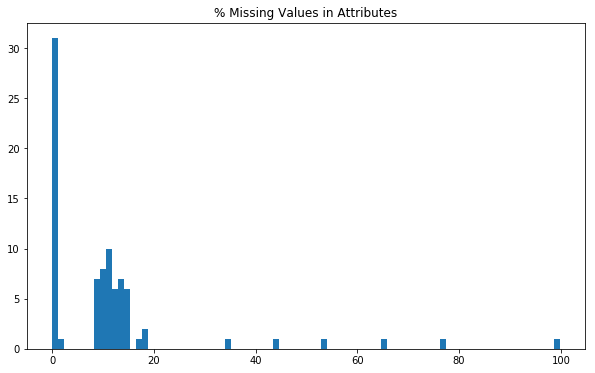

```python
# Investigate patterns in the amount of missing data in each column.
plt.figure(figsize=(10,6))
plt.title("% Missing Values in Attributes")
num_bins = 85
plt.hist(azdias_nan_adjusted_percent, num_bins)
plt.show()
```

Analyzing the distribution in the histogram, we can clearly see that the majority of attributes contain less than 20% of missing values. Visually, I can spot about 6 attributes that contain a range of missing values around ~37% to ~99%.

Next, let's take a closer look at our missing values. We will sort the attributes in descending order and plot in a horizontal barchart with the attribute names clearly visible.

```python
# Sort attributes in descending order
azdias_nan_adjusted_percent_sorted = azdias_nan_adjusted_percent.sort_values(ascending=False)

with pd.option_context('display.max_rows', None, 'display.max_columns', None):
    display(azdias_nan_adjusted_percent_sorted)
```

```
TITEL_KZ                 99.757636
AGER_TYP                 76.955435
KK_KUNDENTYP             65.596749
KBA05_BAUMAX             53.468668
GEBURTSJAHR              44.020282
ALTER_HH                 34.813699
REGIOTYP                 17.735668
KKK                      17.735668
W_KEIT_KIND_HH           16.605084
KBA05_ANTG4              14.959701
KBA05_GBZ                14.959701
MOBI_REGIO               14.959701
KBA05_ANTG1              14.959701
KBA05_ANTG2              14.959701
KBA05_ANTG3              14.959701
PLZ8_GBZ                 13.073637
PLZ8_HHZ                 13.073637
PLZ8_BAUMAX              13.073637
PLZ8_ANTG4               13.073637
PLZ8_ANTG1               13.073637
PLZ8_ANTG3               13.073637
PLZ8_ANTG2               13.073637
SHOPPER_TYP              12.476816
VERS_TYP                 12.476816
HEALTH_TYP               12.476816
NATIONALITAET_KZ         12.153551
PRAEGENDE_JUGENDJAHRE    12.136608
KBA13_ANZAHL_PKW         11.871354
ANZ_HAUSHALTE_AKTIV      11.176913
CAMEO_INTL_2015          11.147852
CAMEO_DEU_2015           11.147852
CAMEO_DEUG_2015          11.147852
LP_LEBENSPHASE_FEIN      10.954859
RELAT_AB                 10.926022
ARBEIT                   10.926022
ORTSGR_KLS9              10.914689
ANZ_HH_TITEL             10.884842
LP_LEBENSPHASE_GROB      10.611509
INNENSTADT               10.518154
EWDICHTE                 10.518154
```

[output cut: 31 more lines]

```
SEMIO_SOZ                 0.000000
SEMIO_REL                 0.000000
SEMIO_MAT                 0.000000
SEMIO_VERT                0.000000
SEMIO_LUST                0.000000
SEMIO_ERL                 0.000000
SEMIO_KULT                0.000000
SEMIO_RAT                 0.000000
SEMIO_KRIT                0.000000
SEMIO_DOM                 0.000000
SEMIO_KAEM                0.000000
SEMIO_PFLICHT             0.000000
SEMIO_TRADV               0.000000
ZABEOTYP                  0.000000
Name: adjusted_missing, dtype: float64
```

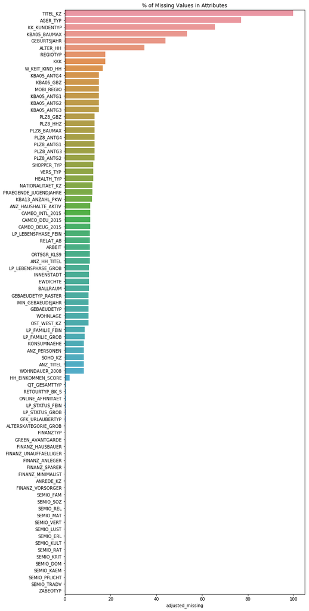

```python
# Plot horizontal barchart
plt.figure(figsize=(10, 25))
plt.title("% of Missing Values in Attributes")
sns.barplot(x=azdias_nan_adjusted_percent_sorted, y=azdias_nan_adjusted_percent_sorted.index)
```

From the above barchart, we can confirm that there are indeed 6 attributes made up more than 20% missing values. Based on the distribution we saw in the histogram, we will label them as outliers. Those attributes are shown below. I have also included the number of attributes that contain more than 20%, 15%, 10%, and 5% missing values.

```python
# Attributes with more than 20% missing values
azdias_nan_adjusted_percent_sorted[azdias_nan_adjusted_percent_sorted > 20]
```

```
TITEL_KZ        99.757636
AGER_TYP        76.955435
KK_KUNDENTYP    65.596749
KBA05_BAUMAX    53.468668
GEBURTSJAHR     44.020282
ALTER_HH        34.813699
Name: adjusted_missing, dtype: float64
```

```python
print("Number of attributes with more than 20% missing values: {}".format(azdias_nan_adjusted_percent_sorted[azdias_nan_adjusted_percent_sorted > 20].count()))
print("Number of attributes with more than 15% missing values: {}".format(azdias_nan_adjusted_percent_sorted[azdias_nan_adjusted_percent_sorted > 15].count()))
print("Number of attributes with more than 10% missing values: {}".format(azdias_nan_adjusted_percent_sorted[azdias_nan_adjusted_percent_sorted > 10].count()))
print("Number of attributes with more than 5% missing values: {}".format(azdias_nan_adjusted_percent_sorted[azdias_nan_adjusted_percent_sorted > 5].count()))
```

```
Number of attributes with more than 20% missing values: 6
Number of attributes with more than 15% missing values: 9
Number of attributes with more than 10% missing values: 46
Number of attributes with more than 5% missing values: 53
```

Let's remove the six outliers from out demographic dataset.

```python
# Remove the outlier columns from the dataset. (You'll perform other data
# engineering tasks such as re-encoding and imputation later.)
outliers = list(azdias_nan_adjusted_percent[azdias_nan_adjusted_percent > 20].index)
azdias_adjusted_no_outliers = azdias_adjusted.drop(columns=outliers)

azdias_adjusted_no_outliers
```

|  | ALTERSKATEGORIE_GROB | ANREDE_KZ | CJT_GESAMTTYP | FINANZ_MINIMALIST | FINANZ_SPARER | FINANZ_VORSORGER | FINANZ_ANLEGER | FINANZ_UNAUFFAELLIGER | FINANZ_HAUSBAUER | FINANZTYP | ... | PLZ8_ANTG1 | PLZ8_ANTG2 | PLZ8_ANTG3 | PLZ8_ANTG4 | PLZ8_BAUMAX | PLZ8_HHZ | PLZ8_GBZ | ARBEIT | ORTSGR_KLS9 | RELAT_AB |
| --- | --- | --- | --- | --- | --- | --- | --- | --- | --- | --- | --- | --- | --- | --- | --- | --- | --- | --- | --- | --- | --- |
| 0 | 2.0 | 1 | 2.0 | 3 | 4 | 3 | 5 | 5 | 3 | 4 | ... | NaN | NaN | NaN | NaN | NaN | NaN | NaN | NaN | NaN | NaN |
| 1 | 1.0 | 2 | 5.0 | 1 | 5 | 2 | 5 | 4 | 5 | 1 | ... | 2.0 | 3.0 | 2.0 | 1.0 | 1.0 | 5.0 | 4.0 | 3.0 | 5.0 | 4.0 |
| 2 | 3.0 | 2 | 3.0 | 1 | 4 | 1 | 2 | 3 | 5 | 1 | ... | 3.0 | 3.0 | 1.0 | 0.0 | 1.0 | 4.0 | 4.0 | 3.0 | 5.0 | 2.0 |
| 3 | 4.0 | 2 | 2.0 | 4 | 2 | 5 | 2 | 1 | 2 | 6 | ... | 2.0 | 2.0 | 2.0 | 0.0 | 1.0 | 3.0 | 4.0 | 2.0 | 3.0 | 3.0 |
| 4 | 3.0 | 1 | 5.0 | 4 | 3 | 4 | 1 | 3 | 2 | 5 | ... | 2.0 | 4.0 | 2.0 | 1.0 | 2.0 | 3.0 | 3.0 | 4.0 | 6.0 | 5.0 |
| 5 | 1.0 | 2 | 2.0 | 3 | 1 | 5 | 2 | 2 | 5 | 2 | ... | 2.0 | 3.0 | 1.0 | 1.0 | 1.0 | 5.0 | 5.0 | 2.0 | 3.0 | 3.0 |
| 6 | 2.0 | 2 | 5.0 | 1 | 5 | 1 | 5 | 4 | 3 | 4 | ... | 3.0 | 3.0 | 1.0 | 0.0 | 1.0 | 5.0 | 5.0 | 4.0 | 6.0 | 3.0 |
| 7 | 1.0 | 1 | 3.0 | 3 | 3 | 4 | 1 | 3 | 2 | 5 | ... | 3.0 | 3.0 | 1.0 | 0.0 | 1.0 | 4.0 | 4.0 | 2.0 | 5.0 | 2.0 |
| 8 | 3.0 | 1 | 3.0 | 4 | 4 | 2 | 4 | 2 | 2 | 6 | ... | 2.0 | 3.0 | 2.0 | 1.0 | 1.0 | 3.0 | 3.0 | 2.0 | 4.0 | 3.0 |
| 9 | 3.0 | 2 | 4.0 | 2 | 4 | 2 | 3 | 5 | 4 | 1 | ... | 2.0 | 3.0 | 2.0 | 1.0 | 1.0 | 3.0 | 3.0 | 2.0 | 3.0 | 1.0 |
| 10 | 3.0 | 2 | 1.0 | 2 | 2 | 5 | 3 | 1 | 5 | 6 | ... | 2.0 | 4.0 | 2.0 | 0.0 | 2.0 | 3.0 | 3.0 | 4.0 | 6.0 | 5.0 |
| 11 | 2.0 | 1 | 6.0 | 3 | 4 | 3 | 5 | 5 | 3 | 4 | ... | NaN | NaN | NaN | NaN | NaN | NaN | NaN | NaN | NaN | NaN |
| 12 | 3.0 | 1 | 6.0 | 5 | 3 | 4 | 2 | 4 | 1 | 3 | ... | 3.0 | 3.0 | 1.0 | 0.0 | 1.0 | 5.0 | 5.0 | 3.0 | 6.0 | 4.0 |
| 13 | 1.0 | 2 | 5.0 | 1 | 4 | 3 | 5 | 5 | 2 | 1 | ... | 2.0 | 1.0 | 1.0 | 1.0 | 1.0 | 3.0 | 3.0 | 3.0 | 6.0 | 4.0 |
| 14 | 3.0 | 1 | 6.0 | 3 | 4 | 3 | 5 | 5 | 3 | 4 | ... | NaN | NaN | NaN | NaN | NaN | NaN | NaN | NaN | NaN | NaN |
| 15 | 4.0 | 2 | 4.0 | 4 | 1 | 5 | 1 | 1 | 4 | 2 | ... | NaN | NaN | NaN | NaN | NaN | NaN | NaN | 4.0 | 8.0 | 5.0 |
| 16 | 1.0 | 2 | 1.0 | 4 | 3 | 1 | 4 | 5 | 1 | 3 | ... | 3.0 | 3.0 | 1.0 | 0.0 | 1.0 | 3.0 | 4.0 | 1.0 | 2.0 | 1.0 |
| 17 | 2.0 | 1 | 6.0 | 3 | 4 | 3 | 5 | 5 | 3 | 4 | ... | NaN | NaN | NaN | NaN | NaN | NaN | NaN | NaN | NaN | NaN |
| 18 | 2.0 | 2 | 6.0 | 2 | 4 | 1 | 5 | 4 | 1 | 1 | ... | 2.0 | 3.0 | 2.0 | 1.0 | 1.0 | 3.0 | 3.0 | 3.0 | 4.0 | 3.0 |
| 19 | 3.0 | 1 | 3.0 | 5 | 2 | 3 | 1 | 3 | 1 | 5 | ... | 2.0 | 4.0 | 2.0 | 1.0 | 2.0 | 5.0 | 4.0 | 4.0 | 6.0 | 3.0 |
| 20 | 2.0 | 2 | 4.0 | 4 | 3 | 1 | 4 | 5 | 1 | 3 | ... | NaN | NaN | NaN | NaN | NaN | NaN | NaN | 3.0 | 4.0 | 1.0 |
| 21 | 2.0 | 1 | 3.0 | 3 | 4 | 1 | 2 | 5 | 1 | 3 | ... | 1.0 | 4.0 | 3.0 | 2.0 | 4.0 | 4.0 | 3.0 | 5.0 | 7.0 | 5.0 |
| 22 | 1.0 | 1 | 4.0 | 1 | 5 | 3 | 5 | 5 | 5 | 1 | ... | 2.0 | 4.0 | 2.0 | 1.0 | 2.0 | 4.0 | 3.0 | 4.0 | 5.0 | 5.0 |
| 23 | 3.0 | 1 | 3.0 | 5 | 3 | 3 | 2 | 2 | 1 | 6 | ... | NaN | NaN | NaN | NaN | NaN | NaN | NaN | 3.0 | 6.0 | 2.0 |
| 24 | 3.0 | 2 | 6.0 | 3 | 4 | 3 | 5 | 5 | 3 | 4 | ... | NaN | NaN | NaN | NaN | NaN | NaN | NaN | NaN | NaN | NaN |
| 25 | 1.0 | 1 | 3.0 | 3 | 5 | 3 | 5 | 4 | 3 | 4 | ... | 2.0 | 2.0 | 0.0 | 0.0 | 1.0 | 4.0 | 5.0 | 3.0 | 2.0 | 5.0 |
| 26 | 3.0 | 1 | 3.0 | 5 | 2 | 4 | 2 | 3 | 1 | 3 | ... | NaN | NaN | NaN | NaN | NaN | NaN | NaN | 4.0 | 3.0 | 5.0 |
| 27 | 3.0 | 1 | 4.0 | 3 | 3 | 4 | 1 | 2 | 2 | 5 | ... | 2.0 | 3.0 | 3.0 | 2.0 | 4.0 | 5.0 | 3.0 | 4.0 | 7.0 | 5.0 |
| 28 | 3.0 | 1 | 2.0 | 3 | 2 | 4 | 3 | 3 | 2 | 3 | ... | 3.0 | 3.0 | 1.0 | 0.0 | 1.0 | 5.0 | 5.0 | 3.0 | 4.0 | 1.0 |
| 29 | 4.0 | 2 | 1.0 | 5 | 1 | 5 | 2 | 1 | 3 | 6 | ... | 3.0 | 2.0 | 2.0 | 0.0 | 1.0 | 3.0 | 4.0 | 2.0 | 4.0 | 3.0 |
| ... | ... | ... | ... | ... | ... | ... | ... | ... | ... | ... | ... | ... | ... | ... | ... | ... | ... | ... | ... | ... | ... |
| 891191 | 4.0 | 2 | 1.0 | 4 | 1 | 5 | 1 | 1 | 4 | 2 | ... | 3.0 | 3.0 | 1.0 | 0.0 | 1.0 | 4.0 | 5.0 | 1.0 | 3.0 | 1.0 |
| 891192 | 1.0 | 2 | 3.0 | 1 | 5 | 2 | 5 | 3 | 5 | 1 | ... | 4.0 | 2.0 | 1.0 | 0.0 | 1.0 | 3.0 | 3.0 | 3.0 | 5.0 | 1.0 |
| 891193 | 4.0 | 1 | 3.0 | 4 | 1 | 5 | 1 | 2 | 5 | 5 | ... | 2.0 | 4.0 | 1.0 | 0.0 | 2.0 | 2.0 | 2.0 | 4.0 | 6.0 | 4.0 |
| 891194 | 3.0 | 1 | 4.0 | 4 | 3 | 4 | 2 | 3 | 1 | 3 | ... | 3.0 | 2.0 | 2.0 | 0.0 | 1.0 | 4.0 | 4.0 | 4.0 | 8.0 | 5.0 |
| 891195 | 4.0 | 2 | 6.0 | 3 | 1 | 5 | 1 | 1 | 5 | 2 | ... | 2.0 | 3.0 | 2.0 | 1.0 | 1.0 | 4.0 | 3.0 | 4.0 | 7.0 | 5.0 |
| 891196 | 2.0 | 2 | 6.0 | 1 | 5 | 2 | 5 | 4 | 3 | 1 | ... | 2.0 | 3.0 | 2.0 | 1.0 | 1.0 | 3.0 | 3.0 | 3.0 | 4.0 | 5.0 |
| 891197 | 3.0 | 2 | 1.0 | 3 | 2 | 4 | 1 | 3 | 3 | 5 | ... | 2.0 | 3.0 | 2.0 | 1.0 | 1.0 | 4.0 | 4.0 | 3.0 | 9.0 | 5.0 |
| 891198 | 3.0 | 1 | 5.0 | 2 | 5 | 3 | 4 | 5 | 3 | 1 | ... | 4.0 | 2.0 | 1.0 | 0.0 | 1.0 | 4.0 | 5.0 | 3.0 | 9.0 | 5.0 |
| 891199 | 2.0 | 1 | 3.0 | 2 | 5 | 2 | 3 | 3 | 4 | 1 | ... | 1.0 | 4.0 | 3.0 | 2.0 | 5.0 | 5.0 | 3.0 | 3.0 | 7.0 | 3.0 |
| 891200 | 1.0 | 2 | 3.0 | 1 | 5 | 3 | 5 | 5 | 5 | 1 | ... | 1.0 | 4.0 | 2.0 | 1.0 | 2.0 | 3.0 | 3.0 | 4.0 | 6.0 | 5.0 |
| 891201 | 3.0 | 1 | 3.0 | 4 | 2 | 3 | 2 | 2 | 3 | 6 | ... | 1.0 | 4.0 | 3.0 | 1.0 | 3.0 | 4.0 | 3.0 | 3.0 | 7.0 | 5.0 |
| 891202 | 2.0 | 2 | 5.0 | 1 | 4 | 1 | 2 | 5 | 4 | 1 | ... | 1.0 | 4.0 | 3.0 | 2.0 | 5.0 | 4.0 | 2.0 | 4.0 | 8.0 | 5.0 |
| 891203 | 4.0 | 2 | 1.0 | 4 | 1 | 5 | 1 | 3 | 4 | 5 | ... | 2.0 | 3.0 | 2.0 | 1.0 | 1.0 | 3.0 | 3.0 | 4.0 | 8.0 | 5.0 |
| 891204 | 3.0 | 1 | 5.0 | 4 | 3 | 4 | 4 | 2 | 1 | 6 | ... | 2.0 | 3.0 | 1.0 | 0.0 | 1.0 | 3.0 | 4.0 | 4.0 | 7.0 | 3.0 |
| 891205 | 4.0 | 1 | 2.0 | 4 | 2 | 4 | 3 | 3 | 4 | 2 | ... | 1.0 | 4.0 | 3.0 | 1.0 | 3.0 | 3.0 | 2.0 | 3.0 | 7.0 | 5.0 |
| 891206 | 1.0 | 2 | 4.0 | 3 | 4 | 2 | 4 | 4 | 2 | 4 | ... | 3.0 | 2.0 | 1.0 | 0.0 | 1.0 | 4.0 | 5.0 | 3.0 | 4.0 | 3.0 |
| 891207 | 3.0 | 2 | 1.0 | 5 | 1 | 5 | 1 | 2 | 4 | 2 | ... | 2.0 | 3.0 | 2.0 | 2.0 | 4.0 | 4.0 | 2.0 | 1.0 | 5.0 | 1.0 |
| 891208 | 4.0 | 1 | 2.0 | 5 | 2 | 4 | 2 | 3 | 1 | 6 | ... | 3.0 | 2.0 | 0.0 | 0.0 | 1.0 | 3.0 | 3.0 | 4.0 | 2.0 | 5.0 |
| 891209 | 1.0 | 2 | 5.0 | 1 | 4 | 2 | 3 | 4 | 4 | 1 | ... | 1.0 | 4.0 | 2.0 | 1.0 | 5.0 | 5.0 | 4.0 | 4.0 | 5.0 | 5.0 |
| 891210 | 3.0 | 1 | 5.0 | 3 | 3 | 4 | 2 | 2 | 2 | 6 | ... | 2.0 | 3.0 | 2.0 | 1.0 | 1.0 | 3.0 | 3.0 | 3.0 | 9.0 | 5.0 |
| 891211 | 3.0 | 1 | 2.0 | 3 | 2 | 4 | 3 | 3 | 2 | 2 | ... | 1.0 | 4.0 | 2.0 | 0.0 | 2.0 | 3.0 | 2.0 | 3.0 | 5.0 | 5.0 |
| 891212 | 4.0 | 1 | 1.0 | 3 | 1 | 5 | 1 | 1 | 5 | 5 | ... | 1.0 | 3.0 | 3.0 | 2.0 | 5.0 | 4.0 | 1.0 | 3.0 | 9.0 | 5.0 |
| 891213 | 4.0 | 2 | 5.0 | 3 | 3 | 3 | 5 | 3 | 2 | 6 | ... | 2.0 | 4.0 | 2.0 | 1.0 | 2.0 | 5.0 | 5.0 | 3.0 | 4.0 | 4.0 |
| 891214 | 1.0 | 2 | 4.0 | 1 | 5 | 2 | 3 | 3 | 4 | 1 | ... | 1.0 | 4.0 | 3.0 | 2.0 | 5.0 | 5.0 | 2.0 | 3.0 | 7.0 | 3.0 |
| 891215 | 2.0 | 2 | 6.0 | 1 | 5 | 2 | 4 | 5 | 4 | 1 | ... | 2.0 | 4.0 | 2.0 | 1.0 | 2.0 | 4.0 | 4.0 | 2.0 | 5.0 | 2.0 |
| 891216 | 3.0 | 2 | 5.0 | 1 | 4 | 2 | 5 | 4 | 4 | 1 | ... | 3.0 | 2.0 | 0.0 | 0.0 | 1.0 | 2.0 | 3.0 | NaN | NaN | NaN |
| 891217 | 2.0 | 1 | 4.0 | 3 | 3 | 3 | 2 | 2 | 3 | 6 | ... | 1.0 | 3.0 | 3.0 | 2.0 | 4.0 | 5.0 | 3.0 | 4.0 | 6.0 | 5.0 |
| 891218 | 2.0 | 2 | 4.0 | 2 | 4 | 2 | 5 | 4 | 3 | 1 | ... | 4.0 | 2.0 | 0.0 | 0.0 | 1.0 | 3.0 | 4.0 | 2.0 | 2.0 | 3.0 |
| 891219 | 1.0 | 1 | 3.0 | 1 | 5 | 3 | 5 | 5 | 5 | 1 | ... | 1.0 | 4.0 | 3.0 | 1.0 | 5.0 | 1.0 | 1.0 | 4.0 | 7.0 | 5.0 |
| 891220 | 4.0 | 1 | 1.0 | 4 | 2 | 5 | 2 | 1 | 5 | 6 | ... | 3.0 | 3.0 | 1.0 | 0.0 | 1.0 | 4.0 | 4.0 | 3.0 | 4.0 | 5.0 |

891221 rows × 79 columns

```python
# Drop outliers from feat_info
feat_outliers_idx = feat_info[feat_info['attribute'].isin(outliers)].index.tolist()
feat_info_no_outliers = feat_info.drop(feat_outliers_idx)
```

#### Discussion 1.1.2: Assess Missing Data in Each Column

Through the previous steps we have noted, from 85 attributes, there are 6 attributes that contain more than 20% missing values, 9 that contain more than 15%, 46 that contain more than 10%, and 53 that contain more than 5%.

Using a histogram distribution we were able to label attributes that contain more than 20% missing values as outliers. There are a total of six outliers that have been removed from our demographic dataset. They are:

1. TITEL_KZ - 99.757636% missing values
2. AGER_TYP - 76.955435% missing values
3. KK_KUNDENTYP - 65.596749% missing values
4. KBA05_BAUMAX - 53.468668% missing values
5. GEBURTSJAHR - 44.020282 missing values
6. ALTER_HH - 34.813699% missing values

If we examine the sorted attributes in `azdias_nan_adjusted_percent_sorted` above, we notice there are a number of groupings where attributes contain the exact same percent of missing values. Those groupings are:

- **17.735668** : REGIOTYP, KKK
- **14.959701** : KBA05_ANTG4, KBA05_GBZ, MOBI_REGIO, KBA05_ANTG1, KBA05_ANTG2, KBA05_ANTG3
- **13.073637** : PLZ8_GBZ, PLZ8_HHZ, PLZ8_BAUMAX, PLZ8_ANTG4, PLZ8_ANTG1, PLZ8_ANTG3, PLZ8_ANTG2
- **12.476816** : SHOPPER_TYP, VERS_TYP, HEALTH_TYP
- **11.147852** : CAMEO_INTL_2015, CAMEO_DEU_2015, CAMEO_DEUG_2015
- **10.926022** : RELAT_AB, ARBEIT
- **10.518154** : INNENSTADT, EWDICHTE, BALLRAUM
- **10.451729** : MIN_GEBAEUDEJAHR, GEBAEUDETYP, WOHNLAGE, OST_WEST_KZ
- **8.728699** : LP_FAMILIE_FEIN, LP_FAMILIE_GROB
- **8.247000** : ANZ_PERSONEN, SOHO_KZ, ANZ_TITEL, WOHNDAUER_2008
- **0.544646** : CJT_GESAMTTYP, RETOURTYP_BK_S, ONLINE_AFFINITAET, LP_STATUS_FEIN, LP_STATUS_GROB, GFK_URLAUBERTYP
- **0.000000** : FINANZTYP, GREEN_AVANTGARDE, FINANZ_HAUSBAUER, FINANZ_UNAUFFAELLIGER, FINANZ_ANLEGER, FINANZ_SPARER, FINANZ_MINIMALIST, ANREDE_KZ, FINANZ_VORSORGER, SEMIO_FAM, SEMIO_SOZ, SEMIO_REL, SEMIO_MAT, SEMIO_VERT, SEMIO_LUST, SEMIO_ERL, SEMIO_KULT, SEMIO_RAT, SEMIO_KRIT, SEMIO_DOM, SEMIO_KAEM, SEMIO_PFLICHT, SEMIO_TRADV, ZABEOTYP

#### Step 1.1.3: Assess Missing Data in Each Row

Now, you'll perform a similar assessment for the rows of the dataset. How much data is missing in each row? As with the columns, you should see some groups of points that have a very different numbers of missing values. Divide the data into two subsets: one for data points that are above some threshold for missing values, and a second subset for points below that threshold.

In order to know what to do with the outlier rows, we should see if the distribution of data values on columns that are not missing data (or are missing very little data) are similar or different between the two groups. Select at least five of these columns and compare the distribution of values.

- You can use seaborn's [`countplot()`](https://seaborn.pydata.org/generated/seaborn.countplot.html) function to create a bar chart of code frequencies and matplotlib's [`subplot()`](https://matplotlib.org/api/_as_gen/matplotlib.pyplot.subplot.html) function to put bar charts for the two subplots side by side.
- To reduce repeated code, you might want to write a function that can perform this comparison, taking as one of its arguments a column to be compared.

Depending on what you observe in your comparison, this will have implications on how you approach your conclusions later in the analysis. If the distributions of non-missing features look similar between the data with many missing values and the data with few or no missing values, then we could argue that simply dropping those points from the analysis won't present a major issue. On the other hand, if the data with many missing values looks very different from the data with few or no missing values, then we should make a note on those data as special. We'll revisit these data later on. **Either way, you should continue your analysis for now using just the subset of the data with few or no missing values.**

Let's first calculate the percent of missing data in each row. Then we will look at its distribution.

```python
# How much data is missing in each row of the dataset?
azdias_nan_rows_percent = 100 * (azdias_adjusted_no_outliers.T.isna().sum()/azdias_adjusted_no_outliers.T.shape[0])
```

```
Text(0.5,0,'% Missing')
```

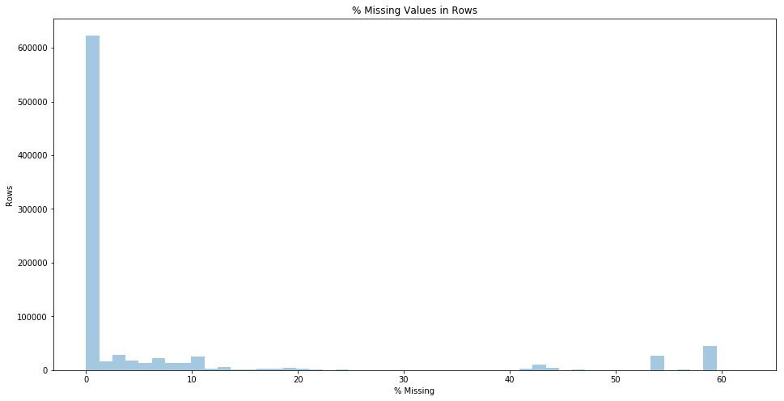

```python
plt.figure(figsize=(16, 8))
sns.distplot(a=azdias_nan_rows_percent, kde=False)
plt.title("% Missing Values in Rows")
plt.ylabel("Rows")
plt.xlabel("% Missing")
```

The distribution above tells us that the majority of rows contain less than 12% of missing values. There is a small grouping of rows around 19%. We can spot obvious outliers above 25%.

For this analysis, we will divide the data into two using a threshold at 12%. One subset of data will contain rows with less than and including 12% missing values, and the other subset will include rows with more than 12% missing values.

```python
# Write code to divide the data into two subsets based on the number of missing
# values in each row.

# Gather the row indexes for subset 1 and subset 2 based on the 12% threshold
# subset 1: Rows with less than or equal to 12% missing values
sub1_idx = azdias_nan_rows_percent[azdias_nan_rows_percent<=12].index

# subset 2: Rows with more than 15% missing values
sub2_idx = azdias_nan_rows_percent[azdias_nan_rows_percent>12].index

print(f"Rows in sub1_idx: {len(sub1_idx)}")
print(f"Rows in sub2_idx: {len(sub2_idx)}")
print(f"Check if all rows accounted for: {len(sub1_idx) + len(sub2_idx)}/891221")
```

```
Rows in sub1_idx: 774743
Rows in sub2_idx: 116478
Check if all rows accounted for: 891221/891221
```

```python
# Create two dataframes for sub1 and sub2 where the required row indexes are dropped
azdias_adjusted_sub1 = azdias_adjusted_no_outliers.drop(sub2_idx, axis=0)
azdias_adjusted_sub2 = azdias_adjusted_no_outliers.drop(sub1_idx, axis=0)

print("Check to ensure shape of data subsets are correct.")
print(f"Shape of sub1 data: {azdias_adjusted_sub1.shape}")
print(f"Shape of sub2 data: {azdias_adjusted_sub2.shape}")
```

```
Check to ensure shape of data subsets are correct.
Shape of sub1 data: (774743, 79)
Shape of sub2 data: (116478, 79)
```

Now that we have our data separated into the two subsets, we want to know if these subsets are qualitatively different. To check, we will compare the two subsets using columns with no missing values.

```python
# Compare the distribution of values for at least five columns where there are
# no or few missing values, between the two subsets.
def plot_subset_comparison(cols):
    """
    Creates two count plots for each column name, one for data subset 1 and one for data subset 2.
    """
    height=6*len(cols)
    plt.figure(figsize=(14, height))
    x = 1
    for i in range(len(cols)):
        plt.subplot(len(cols), 2, x)
        sns.countplot(x=cols[i], data=azdias_adjusted_sub1)
        plt.title("Subset 1: Less than or equal to 12% Missing")
        x += 1

        plt.subplot(len(cols), 2, x)
        sns.countplot(x=cols[i], data=azdias_adjusted_sub2)
        plt.title("Subset 2: More than 12% Missing")
        x += 1
```

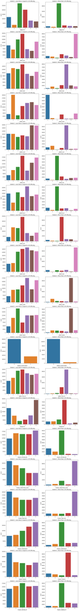

```python
# Retrieve a list of column names. Below, we count the number of NaN values and sort in ascending order.
# We know from before that the first 24 columns have no missing values.
cols = list(azdias_adjusted_no_outliers.isnull().sum().sort_values(ascending=True).index[:20])
plot_subset_comparison(cols)
```

```python
# Keep the dataset where we drop rows with more than 12% missing values.
# Also, we will keep the dataset of the rows we dropped to add as a cluster in the last bit of analysis in this project.
azdias_adjusted_no_outliers = azdias_adjusted_sub1.copy()
azdias_dropped_rows = azdias_adjusted_sub2.copy()
azdias_adjusted_no_outliers.shape
```

```
(774743, 79)
```

#### Discussion 1.1.3: Assess Missing Data in Each Row

We saw in the histogram above that the majority of rows contain less than 12% of missing values. There was a small grouping around 19% and obvious outliers beyond 25%.

We then separated the rows into two subsets split at a threshold of 12%. Subset 1 contained rows with less than or equal to 12% missing values while subset 2 contains rows with more than 12% missing values.

To check if the two subsets were qualitatively different, we compared the two subsets using countplots with columns containing no missing values. Twenty columns were plotted and of those 19 visually appeared to be significantly different. This demonstrates that the data in each subset is significantly different and may hold valuable information.

However, maintaining records in the dataset with a high number of missing values can also lead to its own negative outcomes. For this project, we removed rows with more than 12% missing values. In doing so, we end up keeping 774743 of the original 891221 rows (or 86.9% of records).

### Step 1.2: Select and Re-Encode Features

Checking for missing data isn't the only way in which you can prepare a dataset for analysis. Since the unsupervised learning techniques to be used will only work on data that is encoded numerically, you need to make a few encoding changes or additional assumptions to be able to make progress. In addition, while almost all of the values in the dataset are encoded using numbers, not all of them represent numeric values. Check the third column of the feature summary (`feat_info`) for a summary of types of measurement.

- For numeric and interval data, these features can be kept without changes.
- Most of the variables in the dataset are ordinal in nature. While ordinal values may technically be non-linear in spacing, make the simplifying assumption that the ordinal variables can be treated as being interval in nature (that is, kept without any changes).
- Special handling may be necessary for the remaining two variable types: categorical, and 'mixed'.

In the first two parts of this sub-step, you will perform an investigation of the categorical and mixed-type features and make a decision on each of them, whether you will keep, drop, or re-encode each. Then, in the last part, you will create a new data frame with only the selected and engineered columns.

Data wrangling is often the trickiest part of the data analysis process, and there's a lot of it to be done here. But stick with it: once you're done with this step, you'll be ready to get to the machine learning parts of the project!

```python
# How many features are there of each data type?
feat_info_no_outliers['type'].value_counts()
```

```
ordinal        49
categorical    18
numeric         6
mixed           6
Name: type, dtype: int64
```

Above, we see that our data contains 18 categorical and 6 mixed attributes. We assume that the ordinal variables are treated as interval.

#### Step 1.2.1: Re-Encode Categorical Features

For categorical data, you would ordinarily need to encode the levels as dummy variables. Depending on the number of categories, perform one of the following:

- For binary (two-level) categoricals that take numeric values, you can keep them without needing to do anything.
- There is one binary variable that takes on non-numeric values. For this one, you need to re-encode the values as numbers or create a dummy variable.
- For multi-level categoricals (three or more values), you can choose to encode the values using multiple dummy variables (e.g. via [OneHotEncoder](http://scikit-learn.org/stable/modules/generated/sklearn.preprocessing.OneHotEncoder.html)), or (to keep things straightforward) just drop them from the analysis. As always, document your choices in the Discussion section.

```python
# Assess categorical variables: which are binary, which are multi-level, and
# which one needs to be re-encoded?

# Retrieve all categorical attributes
cat_att_names = feat_info_no_outliers[feat_info_no_outliers['type']=='categorical'].attribute.tolist()
azdias_adjusted_no_outliers.loc[:,cat_att_names].head()
```

|  | ANREDE_KZ | CJT_GESAMTTYP | FINANZTYP | GFK_URLAUBERTYP | GREEN_AVANTGARDE | LP_FAMILIE_FEIN | LP_FAMILIE_GROB | LP_STATUS_FEIN | LP_STATUS_GROB | NATIONALITAET_KZ | SHOPPER_TYP | SOHO_KZ | VERS_TYP | ZABEOTYP | GEBAEUDETYP | OST_WEST_KZ | CAMEO_DEUG_2015 | CAMEO_DEU_2015 |
| --- | --- | --- | --- | --- | --- | --- | --- | --- | --- | --- | --- | --- | --- | --- | --- | --- | --- | --- |
| 1 | 2 | 5.0 | 1 | 10.0 | 0 | 5.0 | 3.0 | 2.0 | 1.0 | 1.0 | 3.0 | 1.0 | 2.0 | 5 | 8.0 | W | 8 | 8A |
| 2 | 2 | 3.0 | 1 | 10.0 | 1 | 1.0 | 1.0 | 3.0 | 2.0 | 1.0 | 2.0 | 0.0 | 1.0 | 5 | 1.0 | W | 4 | 4C |
| 3 | 2 | 2.0 | 6 | 1.0 | 0 | NaN | NaN | 9.0 | 4.0 | 1.0 | 1.0 | 0.0 | 1.0 | 3 | 1.0 | W | 2 | 2A |
| 4 | 1 | 5.0 | 5 | 5.0 | 0 | 10.0 | 5.0 | 3.0 | 2.0 | 1.0 | 2.0 | 0.0 | 2.0 | 4 | 1.0 | W | 6 | 6B |
| 5 | 2 | 2.0 | 2 | 1.0 | 0 | 1.0 | 1.0 | 4.0 | 2.0 | 1.0 | 0.0 | 0.0 | 2.0 | 4 | 1.0 | W | 8 | 8C |

```python
# Count of unique categories (excluding NaN)
azdias_adjusted_no_outliers.loc[:, cat_att_names].nunique(dropna=True)
```

```
ANREDE_KZ            2
CJT_GESAMTTYP        6
FINANZTYP            6
GFK_URLAUBERTYP     12
GREEN_AVANTGARDE     2
LP_FAMILIE_FEIN     11
LP_FAMILIE_GROB      5
LP_STATUS_FEIN      10
LP_STATUS_GROB       5
NATIONALITAET_KZ     3
SHOPPER_TYP          4
SOHO_KZ              2
VERS_TYP             2
ZABEOTYP             6
GEBAEUDETYP          7
OST_WEST_KZ          2
CAMEO_DEUG_2015      9
CAMEO_DEU_2015      44
dtype: int64
```

```python
# Check data types
azdias_adjusted_no_outliers.loc[:,cat_att_names].info()
```

```
<class 'pandas.core.frame.DataFrame'>
Int64Index: 774743 entries, 1 to 891220
Data columns (total 18 columns):
ANREDE_KZ           774743 non-null int64
CJT_GESAMTTYP       774743 non-null float64
FINANZTYP           774743 non-null int64
GFK_URLAUBERTYP     774743 non-null float64
GREEN_AVANTGARDE    774743 non-null int64
LP_FAMILIE_FEIN     750265 non-null float64
LP_FAMILIE_GROB     750265 non-null float64
LP_STATUS_FEIN      774743 non-null float64
LP_STATUS_GROB      774743 non-null float64
NATIONALITAET_KZ    743919 non-null float64
SHOPPER_TYP         741323 non-null float64
SOHO_KZ             774743 non-null float64
VERS_TYP            741323 non-null float64
ZABEOTYP            774743 non-null int64
GEBAEUDETYP         774743 non-null float64
OST_WEST_KZ         774743 non-null object
CAMEO_DEUG_2015     771287 non-null object
CAMEO_DEU_2015      771287 non-null object
dtypes: float64(11), int64(4), object(3)
memory usage: 112.3+ MB
```

Using the count of unique categories and the data type of each attribute, we can narrow down the categories that are binary, multi-level and which need to be re-encoded.

The binary categorical attributes are:

1. ANREDE_KZ
2. GREEN_AVANTGARDE
3. SOHO_KZ
4. VERS_TYP
5. OST_WEST_KZ

Of the 5 listed, only **OST_WEST_KZ** is a string object data type. It will need to be re-encoded. We will also explore the unique values of the remaning four listed.

The remaining categorical attributes are multi-level.

```python
# Re-encode categorical variable(s) to be kept in the analysis.
# Re-encode the OST_WEST_KZ attribute
# Find what two string values are being used
azdias_adjusted_no_outliers['OST_WEST_KZ'].unique()
```

```
array(['W', 'O'], dtype=object)
```

```python
# Replace W and O with 1 and 0 integers
azdias_adjusted_no_outliers['OST_WEST_KZ'] = azdias_adjusted_no_outliers['OST_WEST_KZ'].replace({'W': 1, 'O': 0})
azdias_adjusted_no_outliers['OST_WEST_KZ'].unique()
```

```
array([1, 0])
```

```python
# Examine the other four attribute's unique values
print("ANREDE_KZ: ", azdias_adjusted_no_outliers['ANREDE_KZ'].unique())
print("GREEN_AVANTGARDE: ", azdias_adjusted_no_outliers['GREEN_AVANTGARDE'].unique())
print("SOHO_KZ: ", azdias_adjusted_no_outliers['SOHO_KZ'].unique())
print("VERS_TYP: ", azdias_adjusted_no_outliers['VERS_TYP'].unique())
```

```
ANREDE_KZ:  [2 1]
GREEN_AVANTGARDE:  [0 1]
SOHO_KZ:  [ 1.  0.]
VERS_TYP:  [  2.   1.  nan]
```

```python
# Replacing 2, 1 with 1, 0 will give better results
azdias_adjusted_no_outliers['ANREDE_KZ'].replace({1: 0, 2: 1}, inplace=True)
azdias_adjusted_no_outliers['VERS_TYP'].replace({1: 0, 2: 1}, inplace=True)
```

5 of the 18 categorical attributes have been handled. The remaining are multi-level. Of them, CAMEO_DEU_2015 has the largest number of categories of 44 possible values. The second largest is GFK_URLAUBERTYP with 12. We will keep all multi-level categorical attributes as 44 unique categorical values in CAMEO_DEU_2015 is arguably reasonable with its 771287 non-null values.

```python
# One-Hot encode multi-level attributes
# Retrieve multi-level categorical attribute names
cat_multi_att = []
for i in range(len(cat_att_names)):
    att = cat_att_names[i]
    if azdias_adjusted_no_outliers.loc[:, att].nunique(dropna=True) > 2:
        cat_multi_att.append(att)

print(cat_multi_att)
print(f"Items in cat_multi_att: {len(cat_multi_att)}")
```

```
['CJT_GESAMTTYP', 'FINANZTYP', 'GFK_URLAUBERTYP', 'LP_FAMILIE_FEIN', 'LP_FAMILIE_GROB', 'LP_STATUS_FEIN', 'LP_STATUS_GROB', 'NATIONALITAET_KZ', 'SHOPPER_TYP', 'ZABEOTYP', 'GEBAEUDETYP', 'CAMEO_DEUG_2015', 'CAMEO_DEU_2015']
Items in cat_multi_att: 13
```

```python
# One-Hot encode multi-level attributes in our demographic dataset using the column names
azdias_adjusted_no_outliers = pd.get_dummies(azdias_adjusted_no_outliers, columns=cat_multi_att)

print(azdias_adjusted_no_outliers.shape)
```

```
(774743, 194)
```

```python
azdias_adjusted_no_outliers.head()
```

|  | ALTERSKATEGORIE_GROB | ANREDE_KZ | FINANZ_MINIMALIST | FINANZ_SPARER | FINANZ_VORSORGER | FINANZ_ANLEGER | FINANZ_UNAUFFAELLIGER | FINANZ_HAUSBAUER | GREEN_AVANTGARDE | HEALTH_TYP | ... | CAMEO_DEU_2015_7E | CAMEO_DEU_2015_8A | CAMEO_DEU_2015_8B | CAMEO_DEU_2015_8C | CAMEO_DEU_2015_8D | CAMEO_DEU_2015_9A | CAMEO_DEU_2015_9B | CAMEO_DEU_2015_9C | CAMEO_DEU_2015_9D | CAMEO_DEU_2015_9E |
| --- | --- | --- | --- | --- | --- | --- | --- | --- | --- | --- | --- | --- | --- | --- | --- | --- | --- | --- | --- | --- | --- |
| 1 | 1.0 | 1 | 1 | 5 | 2 | 5 | 4 | 5 | 0 | 3.0 | ... | 0 | 1 | 0 | 0 | 0 | 0 | 0 | 0 | 0 | 0 |
| 2 | 3.0 | 1 | 1 | 4 | 1 | 2 | 3 | 5 | 1 | 3.0 | ... | 0 | 0 | 0 | 0 | 0 | 0 | 0 | 0 | 0 | 0 |
| 3 | 4.0 | 1 | 4 | 2 | 5 | 2 | 1 | 2 | 0 | 2.0 | ... | 0 | 0 | 0 | 0 | 0 | 0 | 0 | 0 | 0 | 0 |
| 4 | 3.0 | 0 | 4 | 3 | 4 | 1 | 3 | 2 | 0 | 3.0 | ... | 0 | 0 | 0 | 0 | 0 | 0 | 0 | 0 | 0 | 0 |
| 5 | 1.0 | 1 | 3 | 1 | 5 | 2 | 2 | 5 | 0 | 3.0 | ... | 0 | 0 | 0 | 1 | 0 | 0 | 0 | 0 | 0 | 0 |

5 rows × 194 columns

We went from 79 to 194 attributes. 115 attributes were added by one-hot encoding. This is correct given the number of unique values in our one-hot encoded multi-levle categorical attributes.

#### Discussion 1.2.1: Re-Encode Categorical Features

We saw that our data contains 18 categorical and 6 mixed attributes. Additionally, we assumed that the ordinal variables are treated as interval. The numerical values did not need re-encoding.

By futher examining the categorical attributes, we discovered which attributes were binary, multi-level and which needed to be re-encoded.

The binary categorical attributes are:

1. ANREDE_KZ
2. GREEN_AVANTGARDE
3. SOHO_KZ
4. VERS_TYP
5. OST_WEST_KZ

Of the 5 listed, only **OST_WEST_KZ** is was string object data type and needed to be re-encoded to integer values of 0 and 1. We went a step further and re-encoded **ANREDE_KZ** and **VERS_TYP** from 2, 1 to 1, 0 to improve the final result.

The remaining categorical attributes were multi-level. The CAMEO_DEU_2015 attribute had the largest number of categories with 44 unique values. The second largest was GFK_URLAUBERTYP with 12. We decided not to drop any multi-level categorical attributes as 44 unique values in CAMEO_DEU_2015 is arguably resonable when compared to its 771287 non-null values. All the multi-level categorical attributes were one-hot encoded. The process resulted in the addition of 115 attributes to our dataframe, where we went from 79 attributes to 194.

#### Step 1.2.2: Engineer Mixed-Type Features

There are a handful of features that are marked as "mixed" in the feature summary that require special treatment in order to be included in the analysis. There are two in particular that deserve attention; the handling of the rest are up to your own choices:

- "PRAEGENDE_JUGENDJAHRE" combines information on three dimensions: generation by decade, movement (mainstream vs. avantgarde), and nation (east vs. west). While there aren't enough levels to disentangle east from west, you should create two new variables to capture the other two dimensions: an interval-type variable for decade, and a binary variable for movement.
- "CAMEO_INTL_2015" combines information on two axes: wealth and life stage. Break up the two-digit codes by their 'tens'-place and 'ones'-place digits into two new ordinal variables (which, for the purposes of this project, is equivalent to just treating them as their raw numeric values).
- If you decide to keep or engineer new features around the other mixed-type features, make sure you note your steps in the Discussion section.

Be sure to check `Data_Dictionary.md` for the details needed to finish these tasks.

```python
# Investigate "PRAEGENDE_JUGENDJAHRE" and engineer two new variables.

# As described in `Data_Dictionary.md
"""
### 1.18. PRAEGENDE_JUGENDJAHRE
Dominating movement of person's youth (avantgarde vs. mainstream; east vs. west)
- -1: unknown
-  0: unknown
-  1: 40s - war years (Mainstream, E+W)
-  2: 40s - reconstruction years (Avantgarde, E+W)
-  3: 50s - economic miracle (Mainstream, E+W)
-  4: 50s - milk bar / Individualisation (Avantgarde, E+W)
-  5: 60s - economic miracle (Mainstream, E+W)
-  6: 60s - generation 68 / student protestors (Avantgarde, W)
-  7: 60s - opponents to the building of the Wall (Avantgarde, E)
-  8: 70s - family orientation (Mainstream, E+W)
-  9: 70s - peace movement (Avantgarde, E+W)
- 10: 80s - Generation Golf (Mainstream, W)
- 11: 80s - ecological awareness (Avantgarde, W)
- 12: 80s - FDJ / communist party youth organisation (Mainstream, E)
- 13: 80s - Swords into ploughshares (Avantgarde, E)
- 14: 90s - digital media kids (Mainstream, E+W)
- 15: 90s - ecological awareness (Avantgarde, E+W)
"""
```

[output not shown]

Investigating the `PRAEGENDE_JUGENDJAHRE` in `Data_Dictionary.md`, we notice we can separate the attribute into generation by decade and movement (mainstream vs. avantgarde). We will store the results in **PRAEGENDE_JUGENDJAHRE_DEC** and **PRAEGENDE_JUGENDJAHRE_MOV**, respecfully.

```python
# Use the information in Data_Dictionary.md to create a dict for PRAEGENDE_JUGENDJAHRE_DEC
# Interval-type variable for decade
pra_dec = {
    1: 40,
    2: 40,
    3: 50,
    4: 50,
    5: 60,
    6: 60,
    7: 60,
    8: 70,
    9: 70,
    10: 80,
    11: 80,
    12: 80,
    13: 80,
    14: 90,
    15: 90
}

# binary variable for movement
# mainstream: 0, avantgarde: 1
pra_mov = {
    1: 0,
    2: 1,
    3: 0,
    4: 1,
    5: 0,
    6: 1,
    7: 1,
    8: 0,
    9: 1,
    10: 0,
    11: 1,
    12: 0,
    13: 1,
    14: 0,
    15: 1
}
```

```python
# Add the new attributes and drop the old one.
azdias_adjusted_no_outliers['PRAEGENDE_JUGENDJAHRE_DEC'] = azdias_adjusted_no_outliers['PRAEGENDE_JUGENDJAHRE'].replace(pra_dec)
azdias_adjusted_no_outliers['PRAEGENDE_JUGENDJAHRE_MOV'] = azdias_adjusted_no_outliers['PRAEGENDE_JUGENDJAHRE'].replace(pra_mov)
azdias_adjusted_no_outliers.drop('PRAEGENDE_JUGENDJAHRE', axis=1, inplace=True)
```

```python
# Check PRAEGENDE_JUGENDJAHRE_DEC and PRAEGENDE_JUGENDJAHRE_MOV were properly encoded
print(f"PRAEGENDE_JUGENDJAHRE_DEC unique values:  {azdias_adjusted_no_outliers['PRAEGENDE_JUGENDJAHRE_DEC'].unique()}")
print(f"PRAEGENDE_JUGENDJAHRE_MOV unique values:  {azdias_adjusted_no_outliers['PRAEGENDE_JUGENDJAHRE_MOV'].unique()}")
```

```
PRAEGENDE_JUGENDJAHRE_DEC unique values:  [ 90.  70.  50.  80.  60.  nan  40.]
PRAEGENDE_JUGENDJAHRE_MOV unique values:  [  0.   1.  nan]
```

```python
# Investigate "CAMEO_INTL_2015" and engineer two new variables.

# As described in `Data_Dictionary.md
"""
German CAMEO: Wealth / Life Stage Typology, mapped to international code
- -1: unknown
- 11: Wealthy Households - Pre-Family Couples & Singles
- 12: Wealthy Households - Young Couples With Children
- 13: Wealthy Households - Families With School Age Children
- 14: Wealthy Households - Older Families &  Mature Couples
- 15: Wealthy Households - Elders In Retirement
- 21: Prosperous Households - Pre-Family Couples & Singles
- 22: Prosperous Households - Young Couples With Children
- 23: Prosperous Households - Families With School Age Children
- 24: Prosperous Households - Older Families & Mature Couples
- 25: Prosperous Households - Elders In Retirement
- 31: Comfortable Households - Pre-Family Couples & Singles
- 32: Comfortable Households - Young Couples With Children
- 33: Comfortable Households - Families With School Age Children
- 34: Comfortable Households - Older Families & Mature Couples
- 35: Comfortable Households - Elders In Retirement
- 41: Less Affluent Households - Pre-Family Couples & Singles
- 42: Less Affluent Households - Young Couples With Children
- 43: Less Affluent Households - Families With School Age Children
- 44: Less Affluent Households - Older Families & Mature Couples
- 45: Less Affluent Households - Elders In Retirement
- 51: Poorer Households - Pre-Family Couples & Singles
- 52: Poorer Households - Young Couples With Children
- 53: Poorer Households - Families With School Age Children
- 54: Poorer Households - Older Families & Mature Couples
- 55: Poorer Households - Elders In Retirement
- XX: unknown
"""
```

[output not shown]

The `CAMEO_INTL_2015` attributes contains wealth in the tenths value (the first digit) and life stage typology in the ones value (the second digit). Let's separate the digits and re-encode the attribute into two new attributes. We will then drop the old attribute.

Let's store wealth in `CAMEO_INTL_2015_W` and life stage in `CAMEO_INTL_2015_LS`.

```python
# Separate as string data type and switch to float
# Wealth: CAMEO_INTL_2015_W
azdias_adjusted_no_outliers['CAMEO_INTL_2015_W'] = azdias_adjusted_no_outliers['CAMEO_INTL_2015'].astype(str)
azdias_adjusted_no_outliers['CAMEO_INTL_2015_W'] = azdias_adjusted_no_outliers['CAMEO_INTL_2015_W'].str[0:1]
# Convert the missing values back to NaN
azdias_adjusted_no_outliers['CAMEO_INTL_2015_W'] = azdias_adjusted_no_outliers['CAMEO_INTL_2015_W'].replace('n', np.NaN)
azdias_adjusted_no_outliers['CAMEO_INTL_2015_W'] = azdias_adjusted_no_outliers['CAMEO_INTL_2015_W'].astype(float)

# Life stage: CAMEO_INTL_2015_LS
azdias_adjusted_no_outliers['CAMEO_INTL_2015_LS'] = azdias_adjusted_no_outliers['CAMEO_INTL_2015'].astype(str)
azdias_adjusted_no_outliers['CAMEO_INTL_2015_LS'] = azdias_adjusted_no_outliers['CAMEO_INTL_2015_LS'].str[1:2]
# Convert the missing values back to NaN
azdias_adjusted_no_outliers['CAMEO_INTL_2015_LS'] = azdias_adjusted_no_outliers['CAMEO_INTL_2015_LS'].replace('a', np.NaN)
azdias_adjusted_no_outliers['CAMEO_INTL_2015_LS'] = azdias_adjusted_no_outliers['CAMEO_INTL_2015_LS'].astype(float)

print("Wealth data type: ", azdias_adjusted_no_outliers['CAMEO_INTL_2015_W'].dtype)
print(f"CAMEO_INTL_2015_W unique values:  {azdias_adjusted_no_outliers['CAMEO_INTL_2015_W'].unique()}")

print("Life Stage data type: ", azdias_adjusted_no_outliers['CAMEO_INTL_2015_LS'].dtype)
print(f"CAMEO_INTL_2015_LS unique values:  {azdias_adjusted_no_outliers['CAMEO_INTL_2015_LS'].unique()}")
```

```
Wealth data type:  float64
CAMEO_INTL_2015_W unique values:  [  5.   2.   1.   4.   3.  nan]
Life Stage data type:  float64
CAMEO_INTL_2015_LS unique values:  [  1.   4.   2.   3.   5.  nan]
```

```python
# Drop the original CAMEO_INTL_2015 attribute
azdias_adjusted_no_outliers.drop('CAMEO_INTL_2015', axis=1, inplace=True)
```

Let's check to see what other mixed attributes we have.

```python
feat_info_no_outliers[feat_info_no_outliers['type']=='mixed']
```

|  | attribute | information_level | type | missing_or_unknown |
| --- | --- | --- | --- | --- |
| 15 | LP_LEBENSPHASE_FEIN | person | mixed | [0] |
| 16 | LP_LEBENSPHASE_GROB | person | mixed | [0] |
| 22 | PRAEGENDE_JUGENDJAHRE | person | mixed | [-1,0] |
| 56 | WOHNLAGE | building | mixed | [-1] |
| 59 | CAMEO_INTL_2015 | microcell_rr4 | mixed | [-1,XX] |
| 79 | PLZ8_BAUMAX | macrocell_plz8 | mixed | [-1,0] |

Other mixed attributes include: `LP_LEBENSPHASE_FEIN`, `LP_LEBENSPHASE_GROB`, `WOHNLAGE`, and `PLZ8_BAUMAX`. Let's drop these from as dataset as they are either not possible to disentangle and/or will result in null values (for example, if you look at `PLZ8_BAUMAX`, the attributes could separate into building type and size but the business building does not have a size with it).

```python
# Drop remaining mixed attributes
azdias_adjusted_no_outliers.drop('LP_LEBENSPHASE_FEIN', axis=1, inplace=True)
azdias_adjusted_no_outliers.drop('LP_LEBENSPHASE_GROB', axis=1, inplace=True)
azdias_adjusted_no_outliers.drop('WOHNLAGE', axis=1, inplace=True)
azdias_adjusted_no_outliers.drop('PLZ8_BAUMAX', axis=1, inplace=True)
```

#### Discussion 1.2.2: Engineer Mixed-Type Features

We re-encoded `PRAEGENDE_JUGENDJAHRE` into two separate attributes named `PRAEGENDE_JUGENDJAHRE_DEC` and `PRAEGENDE_JUGENDJAHRE_MOV` which describes generation decade and movement, respectively. Generation decade uses ordinal values while movement uses binary. The original attribute `PRAEGENDE_JUGENDJAHRE` was dropped from the dataset.

We also re-encoded `CAMEO_INTL_2015` into two separate attributes named `CAMEO_INTL_2015_W` and `CAMEO_INTL_2015_LS` which describes wealth and life style, respectively. Both use ordinal values. The original attribute `CAMEO_INTL_2015` was dropped from the dataset.

The remaining attributes `LP_LEBENSPHASE_FEIN` (Life stage, fine scale), `LP_LEBENSPHASE_GROB` (Life stage, rough scale), `WOHNLAGE` (Neighborhood quality (or rural flag)), and `PLZ8_BAUMAX` (Most common building type within the PLZ8 region) were dropped from the dataset due to difficulty in disentangling.

#### Step 1.2.3: Complete Feature Selection

In order to finish this step up, you need to make sure that your data frame now only has the columns that you want to keep. To summarize, the dataframe should consist of the following:

- All numeric, interval, and ordinal type columns from the original dataset.
- Binary categorical features (all numerically-encoded).
- Engineered features from other multi-level categorical features and mixed features.

Make sure that for any new columns that you have engineered, that you've excluded the original columns from the final dataset. Otherwise, their values will interfere with the analysis later on the project. For example, you should not keep "PRAEGENDE_JUGENDJAHRE", since its values won't be useful for the algorithm: only the values derived from it in the engineered features you created should be retained. As a reminder, your data should only be from **the subset with few or no missing values**.

```python
# If there are other re-engineering tasks you need to perform, make sure you
# take care of them here. (Dealing with missing data will come in step 2.1.)

# Set the azdias dataset to our new azdias_adjusted_no_outliers dataset
azdias = azdias_adjusted_no_outliers.copy()
```

```python
# Do whatever you need to in order to ensure that the dataframe only contains
# the columns that should be passed to the algorithm functions.

azdias.columns
```

```
Index(['ALTERSKATEGORIE_GROB', 'ANREDE_KZ', 'FINANZ_MINIMALIST',
       'FINANZ_SPARER', 'FINANZ_VORSORGER', 'FINANZ_ANLEGER',
       'FINANZ_UNAUFFAELLIGER', 'FINANZ_HAUSBAUER', 'GREEN_AVANTGARDE',
       'HEALTH_TYP',
       ...
       'CAMEO_DEU_2015_8D', 'CAMEO_DEU_2015_9A', 'CAMEO_DEU_2015_9B',
       'CAMEO_DEU_2015_9C', 'CAMEO_DEU_2015_9D', 'CAMEO_DEU_2015_9E',
       'PRAEGENDE_JUGENDJAHRE_DEC', 'PRAEGENDE_JUGENDJAHRE_MOV',
       'CAMEO_INTL_2015_W', 'CAMEO_INTL_2015_LS'],
      dtype='object', length=192)
```

We kept track and dropped unnecessary attributes while we worked. Our dataset correctly has 192 columns. Let's quickly check the data types before moving along.

```python
azdias.info()
```

```
<class 'pandas.core.frame.DataFrame'>
Int64Index: 774743 entries, 1 to 891220
Columns: 192 entries, ALTERSKATEGORIE_GROB to CAMEO_INTL_2015_LS
dtypes: float64(41), int64(23), uint8(128)
memory usage: 478.8 MB
```

### Step 1.3: Create a Cleaning Function

Even though you've finished cleaning up the general population demographics data, it's important to look ahead to the future and realize that you'll need to perform the same cleaning steps on the customer demographics data. In this substep, complete the function below to execute the main feature selection, encoding, and re-engineering steps you performed above. Then, when it comes to looking at the customer data in Step 3, you can just run this function on that DataFrame to get the trimmed dataset in a single step.

```python
def clean_data(df):
    """
    Perform feature trimming, re-encoding, and engineering for demographics
    data

    INPUT: Demographics DataFrame
    OUTPUT: Trimmed and cleaned demographics DataFrame
    """

    ############################################
    # STEP 1: Convert missing value codes into NaNs, ...
    ############################################
    # Identify missing or unknown data values and convert them to NaNs.
    # Set all missing or unknown values to NaN
    for k, v in nan_dict.items():
        df[k].replace(v, np.nan, inplace=True)

    ############################################
    # STEP 2: Remove selected columns and rows, ...
    ############################################
    # Remove the outlier columns containing more than 20% missing values from the dataset
    df = df.drop(columns=outliers)

    # Calculate how much data is missing in each row of the dataset
    df_nan_rows_percent = 100 * (df.T.isna().sum()/df.T.shape[0])

    # Drop rows with more than 12% missing values
    sub_over_12_idx = df_nan_rows_percent[df_nan_rows_percent<=12].index
    df_dropped_rows = df.drop(sub_over_12_idx, axis=0) # We will need this at the end for analysis

    sub_idx = df_nan_rows_percent[df_nan_rows_percent>12].index
    df.drop(sub_idx, axis=0, inplace=True)

    ############################################
    # STEP 3: Select, re-encode, and engineer column values.
    ############################################
    # OST_WEST_KZ: Replace W and O with 1 and 0 integers
    df['OST_WEST_KZ'] = df['OST_WEST_KZ'].replace({'W': 1, 'O': 0})

    # In ANREDE_KZ and VERS_TYP, replace 2, 1 with 1, 0 for better results
    df['ANREDE_KZ'].replace({1: 0, 2: 1}, inplace=True)
    df['VERS_TYP'].replace({1: 0, 2: 1}, inplace=True)

    # One-Hot encode multi-level attributes in our demographic dataset using the column names
    df = pd.get_dummies(df, columns=cat_multi_att)

    # Engineer Mixed-Type Features
    # For PRAEGENDE_JUGENDJAHRE:
    # Add the new attributes and drop the old one.
    df['PRAEGENDE_JUGENDJAHRE_DEC'] = df['PRAEGENDE_JUGENDJAHRE'].replace(pra_dec)
    df['PRAEGENDE_JUGENDJAHRE_MOV'] = df['PRAEGENDE_JUGENDJAHRE'].replace(pra_mov)
    df.drop('PRAEGENDE_JUGENDJAHRE', axis=1, inplace=True)

    # For CAMEO_INTL_2015:
    # Separate as string data type and switch to float
    # Wealth: CAMEO_INTL_2015_W
    df['CAMEO_INTL_2015_W'] = df['CAMEO_INTL_2015'].astype(str)
    df['CAMEO_INTL_2015_W'] = df['CAMEO_INTL_2015_W'].str[0:1]
    # Convert the missing values back to NaN
    df['CAMEO_INTL_2015_W'] = df['CAMEO_INTL_2015_W'].replace('n', np.NaN)
    df['CAMEO_INTL_2015_W'] = df['CAMEO_INTL_2015_W'].astype(float)

    # Life stage: CAMEO_INTL_2015_LS
    df['CAMEO_INTL_2015_LS'] = df['CAMEO_INTL_2015'].astype(str)
    df['CAMEO_INTL_2015_LS'] = df['CAMEO_INTL_2015_LS'].str[1:2]
    # Convert the missing values back to NaN
    df['CAMEO_INTL_2015_LS'] = df['CAMEO_INTL_2015_LS'].replace('a', np.NaN)
    df['CAMEO_INTL_2015_LS'] = df['CAMEO_INTL_2015_LS'].astype(float)

    # Drop the original CAMEO_INTL_2015 attribute
    df.drop('CAMEO_INTL_2015', axis=1, inplace=True)

    # Drop remaining mixed attributes
    df.drop('LP_LEBENSPHASE_FEIN', axis=1, inplace=True)
    df.drop('LP_LEBENSPHASE_GROB', axis=1, inplace=True)
    df.drop('WOHNLAGE', axis=1, inplace=True)
    df.drop('PLZ8_BAUMAX', axis=1, inplace=True)

    # Return the cleaned dataframe.
    return df, df_dropped_rows
```

## Step 2: Feature Transformation

### Step 2.1: Apply Feature Scaling

Before we apply dimensionality reduction techniques to the data, we need to perform feature scaling so that the principal component vectors are not influenced by the natural differences in scale for features. Starting from this part of the project, you'll want to keep an eye on the [API reference page for sklearn](http://scikit-learn.org/stable/modules/classes.html) to help you navigate to all of the classes and functions that you'll need. In this substep, you'll need to check the following:

- sklearn requires that data not have missing values in order for its estimators to work properly. So, before applying the scaler to your data, make sure that you've cleaned the DataFrame of the remaining missing values. This can be as simple as just removing all data points with missing data, or applying an [Imputer](http://scikit-learn.org/stable/modules/generated/sklearn.preprocessing.Imputer.html) to replace all missing values. You might also try a more complicated procedure where you temporarily remove missing values in order to compute the scaling parameters before re-introducing those missing values and applying imputation. Think about how much missing data you have and what possible effects each approach might have on your analysis, and justify your decision in the discussion section below.
- For the actual scaling function, a [StandardScaler](http://scikit-learn.org/stable/modules/generated/sklearn.preprocessing.StandardScaler.html) instance is suggested, scaling each feature to mean 0 and standard deviation 1.
- For these classes, you can make use of the `.fit_transform()` method to both fit a procedure to the data as well as apply the transformation to the data at the same time. Don't forget to keep the fit sklearn objects handy, since you'll be applying them to the customer demographics data towards the end of the project.

```python
# Use an imputer to replace missing values along the columns using a 'median' strategy
imp = Imputer(strategy='median')
imp_azdias = imp.fit_transform(azdias)
```

```python
# Apply feature scaling to the general population demographics data.
scaler = StandardScaler()
standardized_azdias = scaler.fit_transform(imp_azdias)
```

### Discussion 2.1: Apply Feature Scaling

We used an imputer to replace missing NaN values along the columns using a **median** strategy as it is more resistant to the affects of outliers when compared to a mean strategy.

We then standardized the data using a StandardScaler instance. This scaled our features to a mean of 0 and a standard deviation of 1.

### Step 2.2: Perform Dimensionality Reduction

On your scaled data, you are now ready to apply dimensionality reduction techniques.

- Use sklearn's [PCA](http://scikit-learn.org/stable/modules/generated/sklearn.decomposition.PCA.html) class to apply principal component analysis on the data, thus finding the vectors of maximal variance in the data. To start, you should not set any parameters (so all components are computed) or set a number of components that is at least half the number of features (so there's enough features to see the general trend in variability).
- Check out the ratio of variance explained by each principal component as well as the cumulative variance explained. Try plotting the cumulative or sequential values using matplotlib's [`plot()`](https://matplotlib.org/api/_as_gen/matplotlib.pyplot.plot.html) function. Based on what you find, select a value for the number of transformed features you'll retain for the clustering part of the project.
- Once you've made a choice for the number of components to keep, make sure you re-fit a PCA instance to perform the decided-on transformation.

```python
# Apply PCA to the data.
pca = PCA()
X_pca = pca.fit_transform(standardized_azdias)
```

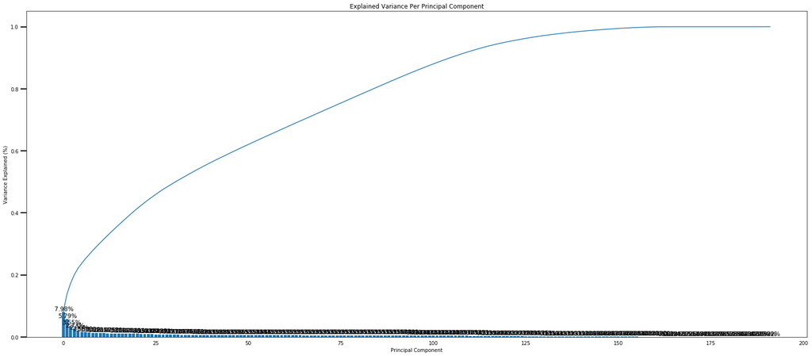

```python
# Investigate the variance accounted for by each principal component.
def scree_plot(pca):
    '''
    REFERENCE:
    Title: Interpret_PCA_Results_SC
    Author: Udacity Intro to Machine Learning: Unsupervised Learning - Lesson 4.13
    Availability: https://classroom.udacity.com/nanodegrees/nd229/parts/78c059d0-dff0-44ee-b737-2fcd5cef2ccb/modules/2ad2c343-3cf6-4bdd-9e00-5aa6c13325f3/lessons/dd43ee95-8403-4b8b-8574-ef5f41aa22bf/concepts/8fb00610-ab64-4da3-b142-4f991012d45a


    Creates a scree plot associated with the principal components

    INPUT: pca - the result of instantian of PCA in scikit learn

    OUTPUT:
            None
    '''
    num_components = len(pca.explained_variance_ratio_)
    ind = np.arange(num_components)
    vals = pca.explained_variance_ratio_

    plt.figure(figsize=(28, 12))
    ax = plt.subplot(111)
    cumvals = np.cumsum(vals)
    ax.bar(ind, vals)
    ax.plot(ind, cumvals)
    for i in range(num_components):
        ax.annotate(r"%s%%" % ((str(vals[i]*100)[:4])), (ind[i]+0.2, vals[i]), va="bottom", ha="center", fontsize=12)

    ax.xaxis.set_tick_params(width=0)
    ax.yaxis.set_tick_params(width=2, length=12)

    ax.set_xlabel("Principal Component")
    ax.set_ylabel("Variance Explained (%)")
    plt.title('Explained Variance Per Principal Component')

scree_plot(pca)
```

We used the `explained_variance_ratio_` method above to investigate the amount of variance accounted for by each principal component. The first principal component accounted for 7.98% of variance, the second 5.79%, etc.

Let's re-examine PCA using 125 components

```python
# Re-apply PCA to the data while selecting for number of components to retain.
pca = PCA(125)
X_pca = pca.fit_transform(standardized_azdias)
```

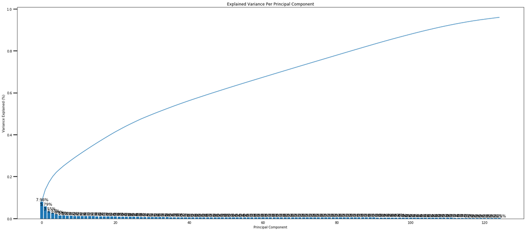

```python
scree_plot(pca)
```

### Discussion 2.2: Perform Dimensionality Reduction

We first applied PCA to all features in the `standardized_azdias` dataset. Using `explained_variance_ratio_`, we found that the first principal component accounted for 7.98% of variance, the second 5.79%, etc.

Ideally, we want to capture as much variance as possible. However, in general, the more principal components we keep the slower our computation will be. We can also get to a point where keeping certain principal components adds to the computation time but only gives us a small amount of additional variance.

### Step 2.3: Interpret Principal Components

Now that we have our transformed principal components, it's a nice idea to check out the weight of each variable on the first few components to see if they can be interpreted in some fashion.

As a reminder, each principal component is a unit vector that points in the direction of highest variance (after accounting for the variance captured by earlier principal components). The further a weight is from zero, the more the principal component is in the direction of the corresponding feature. If two features have large weights of the same sign (both positive or both negative), then increases in one tend expect to be associated with increases in the other. To contrast, features with different signs can be expected to show a negative correlation: increases in one variable should result in a decrease in the other.

- To investigate the features, you should map each weight to their corresponding feature name, then sort the features according to weight. The most interesting features for each principal component, then, will be those at the beginning and end of the sorted list. Use the data dictionary document to help you understand these most prominent features, their relationships, and what a positive or negative value on the principal component might indicate.
- You should investigate and interpret feature associations from the first three principal components in this substep. To help facilitate this, you should write a function that you can call at any time to print the sorted list of feature weights, for the *i*-th principal component. This might come in handy in the next step of the project, when you interpret the tendencies of the discovered clusters.

```python
# Map weights for the first principal component to corresponding feature names
# and then print the linked values, sorted by weight.
def plot_component(df, pca, comp):
    """
    REFERENCE: This is a modified function originally taken from the Udacity helper_function.py pca_results()
    Title: helper_functions.py pca_results()
    Author: Udacity Intro to Machine Learning: Unsupervised Learning - Lesson 4
    Availability: https://view3854ccca.udacity-student-workspaces.com/edit/helper_functions.py


    Prints and Plots the variance of features in a specific principal component
    """
    # PCA components
    components = pd.DataFrame(np.round(pca.components_, 4), columns=df.keys())
    components = components.iloc[comp-1]
    components.sort_values(ascending=False, inplace=True)

    # Grab the head and end of each for plotting
    components_pos = components.head()
    components_neg = components.tail()
    components_plot = pd.concat([components_pos, components_neg])

    # Create a bar plot visualization
    fig, ax = plt.subplots(figsize = (16,9))

    # Plot the feature weights as a function of the components
    components_plot.plot(ax = ax, kind = 'bar');
    ax.set_ylabel("Feature Weights")
    ax.set_xticklabels(components.index, rotation=60)
    ax.set_title(f"Feature Weights in Component {comp}")

    # Return a concatenated DataFrame
    return components
```

```
LP_STATUS_GROB_1.0           0.1965
HH_EINKOMMEN_SCORE           0.1863
CAMEO_INTL_2015_W            0.1857
PLZ8_ANTG3                   0.1822
PLZ8_ANTG4                   0.1763
ORTSGR_KLS9                  0.1542
EWDICHTE                     0.1529
FINANZ_HAUSBAUER             0.1489
KBA05_ANTG4                  0.1293
LP_STATUS_FEIN_1.0           0.1271
PLZ8_ANTG2                   0.1252
KBA05_ANTG3                  0.1176
FINANZ_SPARER                0.1168
LP_STATUS_FEIN_2.0           0.1162
ANZ_HAUSHALTE_AKTIV          0.1155
FINANZTYP_1                  0.1140
CAMEO_DEUG_2015_9            0.1138
ARBEIT                       0.1135
RELAT_AB                     0.1072
CAMEO_DEUG_2015_8            0.0923
LP_FAMILIE_GROB_1.0          0.0872
LP_FAMILIE_FEIN_1.0          0.0872
SEMIO_PFLICHT                0.0850
SEMIO_REL                    0.0806
ZABEOTYP_5                   0.0768
PRAEGENDE_JUGENDJAHRE_DEC    0.0742
SEMIO_RAT                    0.0709
GEBAEUDETYP_3.0              0.0671
CAMEO_DEU_2015_8A            0.0637
SEMIO_TRADV                  0.0611
                              ...
WOHNDAUER_2008              -0.0544
KBA13_ANZAHL_PKW            -0.0612
CAMEO_DEUG_2015_3           -0.0658
LP_FAMILIE_GROB_5.0         -0.0660
NATIONALITAET_KZ_1.0        -0.0671
CAMEO_DEUG_2015_4           -0.0726
FINANZTYP_2                 -0.0792
ANZ_PERSONEN                -0.0837
FINANZ_VORSORGER            -0.0857
ALTERSKATEGORIE_GROB        -0.0858
GEBAEUDETYP_1.0             -0.0885
CAMEO_DEUG_2015_2           -0.0893
BALLRAUM                    -0.0959
GEBAEUDETYP_RASTER          -0.0968
ZABEOTYP_1                  -0.0968
GREEN_AVANTGARDE            -0.1059
PRAEGENDE_JUGENDJAHRE_MOV   -0.1059
LP_STATUS_FEIN_9.0          -0.1102
CAMEO_INTL_2015_LS          -0.1113
LP_STATUS_GROB_4.0          -0.1120
LP_STATUS_GROB_5.0          -0.1162
LP_STATUS_FEIN_10.0         -0.1162
INNENSTADT                  -0.1269
PLZ8_GBZ                    -0.1336
KONSUMNAEHE                 -0.1361
KBA05_GBZ                   -0.1813
PLZ8_ANTG1                  -0.1829
KBA05_ANTG1                 -0.1897
FINANZ_MINIMALIST           -0.1921
MOBI_REGIO                  -0.2051
Name: 0, Length: 192, dtype: float64
```

[figure not shown]

```python
plot_component(azdias, pca, 1)
```

```
ALTERSKATEGORIE_GROB         0.2325
FINANZ_VORSORGER             0.2179
ZABEOTYP_3                   0.2000
SEMIO_ERL                    0.1806
SEMIO_LUST                   0.1629
RETOURTYP_BK_S               0.1567
W_KEIT_KIND_HH               0.1274
CJT_GESAMTTYP_2.0            0.1077
LP_STATUS_FEIN_1.0           0.0983
FINANZTYP_5                  0.0974
FINANZTYP_2                  0.0899
FINANZ_HAUSBAUER             0.0874
FINANZ_MINIMALIST            0.0859
SHOPPER_TYP_3.0              0.0753
SEMIO_KRIT                   0.0749
CJT_GESAMTTYP_1.0            0.0705
PLZ8_ANTG3                   0.0683
FINANZTYP_6                  0.0665
EWDICHTE                     0.0657
NATIONALITAET_KZ_1.0         0.0648
ORTSGR_KLS9                  0.0645
PLZ8_ANTG4                   0.0644
LP_FAMILIE_FEIN_1.0          0.0608
LP_FAMILIE_GROB_1.0          0.0608
CAMEO_INTL_2015_W            0.0603
GFK_URLAUBERTYP_4.0          0.0591
SEMIO_KAEM                   0.0584
KBA05_ANTG4                  0.0536
WOHNDAUER_2008               0.0532
ARBEIT                       0.0503
                              ...
PLZ8_GBZ                    -0.0526
CJT_GESAMTTYP_4.0           -0.0549
KBA05_ANTG1                 -0.0566
ZABEOTYP_1                  -0.0604
SEMIO_SOZ                   -0.0629
KBA05_GBZ                   -0.0644
MOBI_REGIO                  -0.0659
ANZ_PERSONEN                -0.0665
PLZ8_ANTG1                  -0.0670
LP_FAMILIE_GROB_4.0         -0.0695
GFK_URLAUBERTYP_9.0         -0.0736
FINANZTYP_3                 -0.0747
LP_STATUS_FEIN_5.0          -0.0817
FINANZTYP_4                 -0.0893
ZABEOTYP_5                  -0.0902
LP_STATUS_FEIN_2.0          -0.0931
ZABEOTYP_4                  -0.1066
SEMIO_MAT                   -0.1292
FINANZTYP_1                 -0.1310
SEMIO_FAM                   -0.1334
ONLINE_AFFINITAET           -0.1628
SEMIO_KULT                  -0.1657
SEMIO_RAT                   -0.1675
FINANZ_ANLEGER              -0.2031
SEMIO_PFLICHT               -0.2054
SEMIO_TRADV                 -0.2077
SEMIO_REL                   -0.2140
FINANZ_UNAUFFAELLIGER       -0.2141
FINANZ_SPARER               -0.2253
PRAEGENDE_JUGENDJAHRE_DEC   -0.2374
Name: 1, Length: 192, dtype: float64
```

[figure not shown]

```python
# Map weights for the second principal component to corresponding feature names
# and then print the linked values, sorted by weight.
plot_component(azdias, pca, 2)
```

```
SEMIO_VERT                   0.3191
SEMIO_FAM                    0.2598
SEMIO_SOZ                    0.2573
SEMIO_KULT                   0.2497
FINANZTYP_5                  0.1365
FINANZ_MINIMALIST            0.1291
SHOPPER_TYP_0.0              0.1233
ZABEOTYP_1                   0.1167
SEMIO_REL                    0.1134
SEMIO_MAT                    0.0880
GREEN_AVANTGARDE             0.0775
PRAEGENDE_JUGENDJAHRE_MOV    0.0775
RETOURTYP_BK_S               0.0759
W_KEIT_KIND_HH               0.0677
EWDICHTE                     0.0650
ORTSGR_KLS9                  0.0648
LP_STATUS_FEIN_10.0          0.0546
LP_STATUS_GROB_5.0           0.0546
SHOPPER_TYP_1.0              0.0512
ZABEOTYP_6                   0.0503
PLZ8_ANTG4                   0.0500
PLZ8_ANTG3                   0.0499
FINANZ_VORSORGER             0.0467
LP_STATUS_FEIN_3.0           0.0456
LP_STATUS_FEIN_1.0           0.0445
PLZ8_ANTG2                   0.0364
RELAT_AB                     0.0354
ARBEIT                       0.0338
LP_STATUS_GROB_3.0           0.0328
GEBAEUDETYP_3.0              0.0311
                              ...
NATIONALITAET_KZ_3.0        -0.0300
LP_STATUS_GROB_2.0          -0.0306
PLZ8_GBZ                    -0.0346
ZABEOTYP_3                  -0.0372
HH_EINKOMMEN_SCORE          -0.0383
KKK                         -0.0400
LP_FAMILIE_FEIN_4.0         -0.0402
GEBAEUDETYP_RASTER          -0.0411
FINANZ_UNAUFFAELLIGER       -0.0456
PLZ8_ANTG1                  -0.0473
PRAEGENDE_JUGENDJAHRE_DEC   -0.0491
KONSUMNAEHE                 -0.0493
SHOPPER_TYP_3.0             -0.0502
BALLRAUM                    -0.0513
FINANZ_SPARER               -0.0552
LP_FAMILIE_GROB_3.0         -0.0559
INNENSTADT                  -0.0578
FINANZ_HAUSBAUER            -0.0621
ZABEOTYP_4                  -0.0639
LP_STATUS_FEIN_4.0          -0.0725
LP_STATUS_FEIN_2.0          -0.0805
SHOPPER_TYP_2.0             -0.0941
FINANZTYP_1                 -0.1002
FINANZ_ANLEGER              -0.1537
SEMIO_RAT                   -0.1542
SEMIO_ERL                   -0.2067
SEMIO_KRIT                  -0.2650
SEMIO_DOM                   -0.2822
SEMIO_KAEM                  -0.3146
ANREDE_KZ                   -0.3446
Name: 2, Length: 192, dtype: float64
```

[figure not shown]

```python
# Map weights for the third principal component to corresponding feature names
# and then print the linked values, sorted by weight.
plot_component(azdias, pca, 3)
```

### Discussion 2.3: Interpret Principal Components

#### Principal Component 1:

The features with the largest postive weights include:

1. LP_STATUS_GROB_1.0 || (low-income earners) || value = 0.1965
2. HH_EINKOMMEN_SCORE || (Estimated household net income) || value = 0.1863
3. CAMEO_INTL_2015_W || (Wealth) || value = 0.1857

and features with the largest negative weights include:

1. MOBI_REGIO || (Movement patterns) || value = -0.2051
2. FINANZ_MINIMALIST || (MINIMALIST: low financial interest) || value = -0.1921
3. KBA05_ANTG1 || (Number of 1-2 family houses in the microcell) || value = -0.1897

#### Principal Component 2:

The features with the largest postive weights include:

1. ALTERSKATEGORIE_GROB || (Estimated age based on given name analysis) || value = 0.2325
2. FINANZ_VORSORGER || (Financial typology: be prepared) || value = 0.2179
3. ZABEOTYP_3 || (Energy consumption typology: fair supplied) || value = 0.2000

and features with the largest negative weights include:

1. PRAEGENDE_JUGENDJAHRE_DEC || (Generational Decade) || value = -0.2374
2. FINANZ_SPARER || (Financial typology: money-saver) || value = -0.2253
3. FINANZ_UNAUFFAELLIGER || (Financial typology: inconspicuous) || value = -0.2141

These features describe a person's age, financial savings, energy consumption, and generational decade. The positive weights describe someone who is older, has modest savings, and is comfortable with a fair amount of energy provided. The negative weights describe someone who is younger and does not have much money saved.

#### Principal Component 3:

The features with the largest postive weights include:

1. SEMIO_VERT || (Personality typology: dreamful) || value = 0.3191
2. SEMIO_FAM || (Personality typology: family-minded) || value = 0.2598
3. SEMIO_SOZ || (Personality typology: socially-minded) || value = 0.2573

and features with the largest negative weights include:

1. ANREDE_KZ || (Gender) || value = -0.3446
2. SEMIO_KAEM || (Personality typology: combative attitude) || value = -0.3146
3. SEMIO_DOM || (Personality typology: dominant-minded) || value = -0.2822

The features describe a person's personality and gender. The positive weights describe a female who is dreamful, social, and familiy orientated. The negative weights describe a male who is combative or dominant.

## Step 3: Clustering

### Step 3.1: Apply Clustering to General Population

You've assessed and cleaned the demographics data, then scaled and transformed them. Now, it's time to see how the data clusters in the principal components space. In this substep, you will apply k-means clustering to the dataset and use the average within-cluster distances from each point to their assigned cluster's centroid to decide on a number of clusters to keep.

- Use sklearn's KMeans class to perform k-means clustering on the PCA-transformed data.
- Then, compute the average difference from each point to its assigned cluster's center. **Hint**: The KMeans object's `.score()` method might be useful here, but note that in sklearn, scores tend to be defined so that larger is better. Try applying it to a small, toy dataset, or use an internet search to help your understanding.
- Perform the above two steps for a number of different cluster counts. You can then see how the average distance decreases with an increasing number of clusters. However, each additional cluster provides a smaller net benefit. Use this fact to select a final number of clusters in which to group the data. **Warning**: because of the large size of the dataset, it can take a long time for the algorithm to resolve. The more clusters to fit, the longer the algorithm will take. You should test for cluster counts through at least 10 clusters to get the full picture, but you shouldn't need to test for a number of clusters above about 30.
- Once you've selected a final number of clusters to use, re-fit a KMeans instance to perform the clustering operation. Make sure that you also obtain the cluster assignments for the general demographics data, since you'll be using them in the final Step 3.3.

```python
def scree_plot_values(clusters, data):
    # Over a number of different cluster counts
    centers, scores = [], []
    for i in range(1, clusters+1):
        centers.append(i)

        # run k-means clustering on the data
        kmeans = KMeans(i)
        model = kmeans.fit(data)
        # compute the average within-cluster distances.
        score = model.score(data)
        score = np.absolute(score)
        scores.append(score)

    return centers, scores

centers, scores = scree_plot_values(30, X_pca)
```

```
Text(0.5,1,'SSE vs K')
```

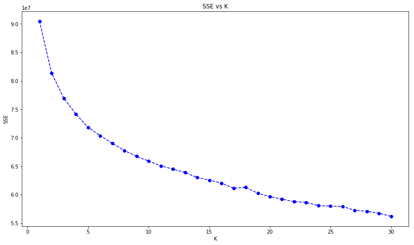

```python
# Investigate the change in within-cluster distance across number of clusters.
# HINT: Use matplotlib's plot function to visualize this relationship.

# Plot Centers and Scores in Scree
plt.figure(figsize=(14, 8))
plt.plot(centers, scores, linestyle='--', marker='o', color='b')
plt.xlabel('K')
plt.ylabel('SSE')
plt.title('SSE vs K')
```

```python
# Re-fit the k-means model with the selected number of clusters and obtain
# cluster predictions for the general population demographics data.
kmeans = KMeans(17)
model = kmeans.fit(X_pca)
labels = model.predict(X_pca)
```

### Discussion 3.1: Apply Clustering to General Population

The Scree plot gives a relatively smooth curve with no obvious elbow. We chose to use a value of 17 clusters as it visually appears to be the last point where we had any 'significant' reduction in the SSE. In fact, there was even a slight increase in SSE at 18 clusters.

### Step 3.2: Apply All Steps to the Customer Data

Now that you have clusters and cluster centers for the general population, it's time to see how the customer data maps on to those clusters. Take care to not confuse this for re-fitting all of the models to the customer data. Instead, you're going to use the fits from the general population to clean, transform, and cluster the customer data. In the last step of the project, you will interpret how the general population fits apply to the customer data.

- Don't forget when loading in the customers data, that it is semicolon (`;`) delimited.
- Apply the same feature wrangling, selection, and engineering steps to the customer demographics using the `clean_data()` function you created earlier. (You can assume that the customer demographics data has similar meaning behind missing data patterns as the general demographics data.)
- Use the sklearn objects from the general demographics data, and apply their transformations to the customers data. That is, you should not be using a `.fit()` or `.fit_transform()` method to re-fit the old objects, nor should you be creating new sklearn objects! Carry the data through the feature scaling, PCA, and clustering steps, obtaining cluster assignments for all of the data in the customer demographics data.

```python
# Load in the customer demographics data.
customers = pd.read_csv('Udacity_CUSTOMERS_Subset.csv', delimiter=";")
```

```python
customers.shape
```

```
(191652, 85)
```

Let's assume that the customer demographic data behaves similarly to the general population in the azdias dataset.

```python
customers, customers_dropped_rows = clean_data(customers)
customers.shape
```

```
(136159, 191)
```

The cleaned customer dataset contains one less column than our general population (191 compared to 192). Let's find out what we're missing.

```python
set(azdias.columns) - set(customers.columns)
```

```
{'GEBAEUDETYP_5.0'}
```

There are no records in the `GEBAEUDETYP` feature with a value of 5 (5 is the one-hot encoded value). Because there are zero records with a value of 5 in the customer data, it means that we can add the feature and set all values to a value of `0` (gives a value of `False` where the value does not equal 5).

```python
customers['GEBAEUDETYP_5.0'] = 0
```

```python
customers.shape
```

```
(136159, 192)
```

```python
# Use an imputer to replace missing values along the columns using a 'median' strategy
imp_customers = imp.fit_transform(customers)

# Apply feature scaling
standardized_customers = scaler.fit_transform(imp_customers)

# Apply PCA to the data.
X_pca_customers = pca.transform(standardized_customers)

# Cluster predictions for the customer data.
labels_customers = model.predict(X_pca_customers)
```

Let's check to see the number of customers in each cluster for the customer and general population datasets.

```python
pd.Series(labels_customers).value_counts()
```

```
13    28240
16    22460
5     13579
3     12507
9     11732
4     10973
10    10584
8      5572
15     5349
2      4961
12     3920
1      2467
0      1093
6       846
14      729
7       581
11      566
dtype: int64
```

```python
pd.Series(labels).value_counts()
```

```
16    93627
2     88958
13    82473
5     79187
3     76992
12    65055
8     54690
4     52126
9     42632
15    41248
10    32799
6     23860
7     15262
1     12735
11     4946
14     4183
0      3970
dtype: int64
```

### Step 3.3: Compare Customer Data to Demographics Data

At this point, you have clustered data based on demographics of the general population of Germany, and seen how the customer data for a mail-order sales company maps onto those demographic clusters. In this final substep, you will compare the two cluster distributions to see where the strongest customer base for the company is.

Consider the proportion of persons in each cluster for the general population, and the proportions for the customers. If we think the company's customer base to be universal, then the cluster assignment proportions should be fairly similar between the two. If there are only particular segments of the population that are interested in the company's products, then we should see a mismatch from one to the other. If there is a higher proportion of persons in a cluster for the customer data compared to the general population (e.g. 5% of persons are assigned to a cluster for the general population, but 15% of the customer data is closest to that cluster's centroid) then that suggests the people in that cluster to be a target audience for the company. On the other hand, the proportion of the data in a cluster being larger in the general population than the customer data (e.g. only 2% of customers closest to a population centroid that captures 6% of the data) suggests that group of persons to be outside of the target demographics.

Take a look at the following points in this step:

- Compute the proportion of data points in each cluster for the general population and the customer data. Visualizations will be useful here: both for the individual dataset proportions, but also to visualize the ratios in cluster representation between groups. Seaborn's [`countplot()`](https://seaborn.pydata.org/generated/seaborn.countplot.html) or [`barplot()`](https://seaborn.pydata.org/generated/seaborn.barplot.html) function could be handy.
  - Recall the analysis you performed in step 1.1.3 of the project, where you separated out certain data points from the dataset if they had more than a specified threshold of missing values. If you found that this group was qualitatively different from the main bulk of the data, you should treat this as an additional data cluster in this analysis. Make sure that you account for the number of data points in this subset, for both the general population and customer datasets, when making your computations!
- Which cluster or clusters are overrepresented in the customer dataset compared to the general population? Select at least one such cluster and infer what kind of people might be represented by that cluster. Use the principal component interpretations from step 2.3 or look at additional components to help you make this inference. Alternatively, you can use the `.inverse_transform()` method of the PCA and StandardScaler objects to transform centroids back to the original data space and interpret the retrieved values directly.
- Perform a similar investigation for the underrepresented clusters. Which cluster or clusters are underrepresented in the customer dataset compared to the general population, and what kinds of people are typified by these clusters?

Before we compare the proportions in each cluster for the datasets, let's add the previously dropped rows (rows with more than 12% missing values) into a cluster of their own for both customers and the general population. This new 18th cluster will have the label **17** as the first cluster starts at 0.

```python
# Use the dropped rows datasets: azdias_dropped_rows and customers_dropped_rows
# Place the records in these datasets into their own cluster in labels and labels_customers

azdias_dropped_rows['label'] = 17
customers_dropped_rows['label'] = 17

gen_pop = pd.Series(labels)
cust = pd.Series(labels_customers)

gen_pop_all = pd.concat([gen_pop, azdias_dropped_rows['label']])
customers_all = pd.concat([cust, customers_dropped_rows['label']])
```

```python
# Check general population
gen_pop_all.value_counts()
```

```
17    116478
16     93627
2      88958
13     82473
5      79187
3      76992
12     65055
8      54690
4      52126
9      42632
15     41248
10     32799
6      23860
7      15262
1      12735
11      4946
14      4183
0       3970
dtype: int64
```

```python
# Check customers
customers_all.value_counts()
```

```
17    55493
13    28240
16    22460
5     13579
3     12507
9     11732
4     10973
10    10584
8      5572
15     5349
2      4961
12     3920
1      2467
0      1093
6       846
14      729
7       581
11      566
dtype: int64
```

```
Text(0.5,0,'Cluster')
```

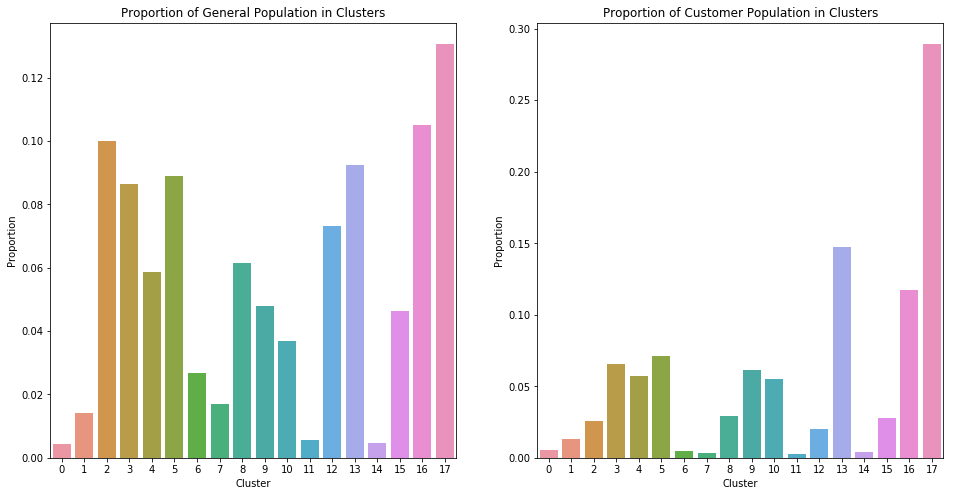

```python
# Compare the proportion of data in each cluster for the customer data to the
# proportion of data in each cluster for the general population.

# Normalize the value_counts() to return proportions (relative frequency)
gen_pop_prop = gen_pop_all.value_counts(normalize=True, sort=False)
gen_pop_prop.rename("general_population", inplace=True)
customer_prop = customers_all.value_counts(normalize=True, sort=False)
customer_prop.rename("customers", inplace=True)

df_compare = pd.concat([gen_pop_prop, customer_prop], axis=1)

plt.figure(figsize=(16,8))

plt.subplot(121)
plt.title('Proportion of General Population in Clusters')
sns.barplot(x=df_compare.index, y=df_compare.general_population)
#sns.barplot(x=customer_proportions.index, y=customer_proportions.proportion)
plt.ylabel("Proportion")
plt.xlabel("Cluster")

plt.subplot(122)
plt.title('Proportion of Customer Population in Clusters')
sns.barplot(x=df_compare.index, y=df_compare.customers)
#sns.barplot(x=customer_proportions.index, y=customer_proportions.proportion)
plt.ylabel("Proportion")
plt.xlabel("Cluster")
```

```
Text(0.5,33,'Cluster')
```

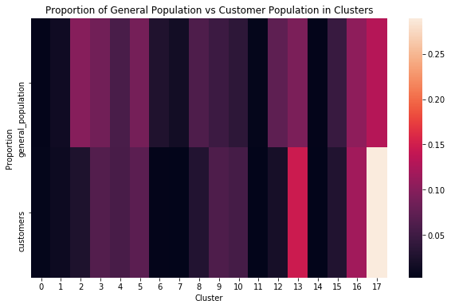

```python
plt.figure(figsize=(10,6))
plt.title('Proportion of General Population vs Customer Population in Clusters')
sns.heatmap(data=df_compare.T)
#sns.barplot(x=customer_proportions.index, y=customer_proportions.proportion)
plt.ylabel("Proportion")
plt.xlabel("Cluster")
```

We can now see the proportion of each dataset that belongs in each cluster. Let's have a closer look and compare the datasets on the same plot and scale.

```python
# Grouped barplot
gen_pop_ds = pd.DataFrame({'proportion': df_compare['general_population'], 'dataset': 'General Population'})
cust_pop_ds = pd.DataFrame({'proportion': df_compare['customers'], 'dataset': 'Customer'})
df_compare_grouped = pd.concat([gen_pop_ds, cust_pop_ds])
```

```
Text(0.5,0,'Cluster')
```

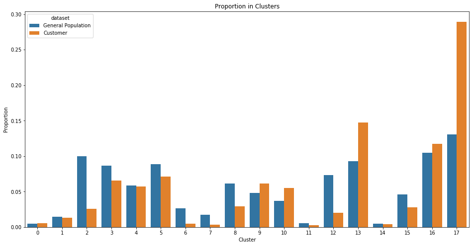

```python
plt.figure(figsize=(16,8))
plt.title('Proportion in Clusters')
sns.barplot(x=df_compare_grouped.index, y=df_compare_grouped.proportion, hue=df_compare_grouped.dataset)
plt.ylabel("Proportion")
plt.xlabel("Cluster")
```

Now we can easily see how the general population compares against our customers in each cluster, on the same scale.

Next, let's calculate the difference between each cluster to have a better idea on if a cluster is over-respresenting or under-representing customer data compared to the general population.

```python
# Calculate the difference between the two clusters
# Positive values signifies over-representing
df_compare['delta'] = df_compare['customers'] - df_compare['general_population']
df_compare
```

|  | general_population | customers | delta |
| --- | --- | --- | --- |
| 0 | 0.004455 | 0.005703 | 0.001248 |
| 1 | 0.014289 | 0.012872 | -0.001417 |
| 2 | 0.099816 | 0.025885 | -0.073930 |
| 3 | 0.086389 | 0.065259 | -0.021130 |
| 4 | 0.058488 | 0.057255 | -0.001233 |
| 5 | 0.088852 | 0.070852 | -0.018000 |
| 6 | 0.026772 | 0.004414 | -0.022358 |
| 7 | 0.017125 | 0.003032 | -0.014093 |
| 8 | 0.061365 | 0.029074 | -0.032292 |
| 9 | 0.047835 | 0.061215 | 0.013380 |
| 10 | 0.036802 | 0.055225 | 0.018423 |
| 11 | 0.005550 | 0.002953 | -0.002596 |
| 12 | 0.072995 | 0.020454 | -0.052542 |
| 13 | 0.092539 | 0.147350 | 0.054811 |
| 14 | 0.004694 | 0.003804 | -0.000890 |
| 15 | 0.046283 | 0.027910 | -0.018373 |
| 16 | 0.105055 | 0.117192 | 0.012137 |
| 17 | 0.130695 | 0.289551 | 0.158856 |

```python
# What kinds of people are part of a cluster that is overrepresented in the
# customer data compared to the general population?

over_rep = df_compare['delta'].sort_values(ascending=False)
over_rep[:3]
```

```
17    0.158856
13    0.054811
10    0.018423
Name: delta, dtype: float64
```

It looks like clusters 17, 13, and 10 are over-representing. Let's have a closer look at the data in those clusters.

```python
# List of columns we wish to examine
# These are the important features that we saw in our pca analysis for the first 3 components
cols = ['LP_STATUS_GROB','HH_EINKOMMEN_SCORE','CAMEO_INTL_2015','MOBI_REGIO','FINANZ_MINIMALIST','KBA05_ANTG1','ALTERSKATEGORIE_GROB','FINANZ_VORSORGER','ZABEOTYP','PRAEGENDE_JUGENDJAHRE','FINANZ_SPARER','FINANZ_UNAUFFAELLIGER','SEMIO_VERT','SEMIO_FAM','SEMIO_SOZ','ANREDE_KZ','SEMIO_KAEM','SEMIO_DOM']
```

```python
# Cluster 17 (the cluster made up of data missing >12% per row)
# We already have the dataset on hand
cluster_17 = azdias_dropped_rows
cluster_17 = cluster_17.mode()
cluster_17[cols].T
```

|  | 0 |
| --- | --- |
| LP_STATUS_GROB | 2 |
| HH_EINKOMMEN_SCORE | 2 |
| CAMEO_INTL_2015 | 23 |
| MOBI_REGIO | 5 |
| FINANZ_MINIMALIST | 3 |
| KBA05_ANTG1 | 0 |
| ALTERSKATEGORIE_GROB | 3 |
| FINANZ_VORSORGER | 3 |
| ZABEOTYP | 3 |
| PRAEGENDE_JUGENDJAHRE | 14 |
| FINANZ_SPARER | 4 |
| FINANZ_UNAUFFAELLIGER | 5 |
| SEMIO_VERT | 1 |
| SEMIO_FAM | 6 |
| SEMIO_SOZ | 2 |
| ANREDE_KZ | 2 |
| SEMIO_KAEM | 6 |
| SEMIO_DOM | 6 |

Cluster 17 is made up of mostly people who are: female, financially prosperous, high income families with school age children with very low movement. They are dreamful, social, non-combative, and non-dominant.

```python
cols = ['LP_STATUS_GROB_1.0','HH_EINKOMMEN_SCORE','CAMEO_INTL_2015_W','MOBI_REGIO','FINANZ_MINIMALIST','KBA05_ANTG1','ALTERSKATEGORIE_GROB','FINANZ_VORSORGER','ZABEOTYP_3','PRAEGENDE_JUGENDJAHRE_DEC','FINANZ_SPARER','FINANZ_UNAUFFAELLIGER','SEMIO_VERT','SEMIO_FAM','SEMIO_SOZ','ANREDE_KZ','SEMIO_KAEM','SEMIO_DOM']
# Cluster 13
cluster_13 = scaler.inverse_transform(pca.inverse_transform(X_pca[labels == 13]))
cluster_13 = pd.DataFrame(cluster_13, columns=azdias.keys()).round()
cluster_13 = cluster_13.mode()
cluster_13[cols].T
```

|  | 0 |
| --- | --- |
| LP_STATUS_GROB_1.0 | -0.0 |
| HH_EINKOMMEN_SCORE | 1.0 |
| CAMEO_INTL_2015_W | 1.0 |
| MOBI_REGIO | 5.0 |
| FINANZ_MINIMALIST | 5.0 |
| KBA05_ANTG1 | 4.0 |
| ALTERSKATEGORIE_GROB | 4.0 |
| FINANZ_VORSORGER | 5.0 |
| ZABEOTYP_3 | -0.0 |
| PRAEGENDE_JUGENDJAHRE_DEC | 0.0 |
| FINANZ_SPARER | 1.0 |
| FINANZ_UNAUFFAELLIGER | 1.0 |
| SEMIO_VERT | 4.0 |
| SEMIO_FAM | 2.0 |
| SEMIO_SOZ | 4.0 |
| ANREDE_KZ | 1.0 |
| SEMIO_KAEM | 5.0 |
| SEMIO_DOM | 5.0 |

```python
# Cluster 10
cluster_10 = scaler.inverse_transform(pca.inverse_transform(X_pca[labels == 10]))
cluster_10 = pd.DataFrame(cluster_10, columns=azdias.keys()).round()
cluster_10 = cluster_10.mode()
cluster_10[cols].T
```

|  | 0 |
| --- | --- |
| LP_STATUS_GROB_1.0 | -0.0 |
| HH_EINKOMMEN_SCORE | 3.0 |
| CAMEO_INTL_2015_W | 2.0 |
| MOBI_REGIO | 5.0 |
| FINANZ_MINIMALIST | 5.0 |
| KBA05_ANTG1 | 3.0 |
| ALTERSKATEGORIE_GROB | 4.0 |
| FINANZ_VORSORGER | 5.0 |
| ZABEOTYP_3 | -0.0 |
| PRAEGENDE_JUGENDJAHRE_DEC | -0.0 |
| FINANZ_SPARER | 1.0 |
| FINANZ_UNAUFFAELLIGER | 1.0 |
| SEMIO_VERT | 7.0 |
| SEMIO_FAM | 4.0 |
| SEMIO_SOZ | 4.0 |
| ANREDE_KZ | -0.0 |
| SEMIO_KAEM | 2.0 |
| SEMIO_DOM | 3.0 |

Cluster 10 is made up of mostly people who are: high income earners, over 60 years old, have very low movement, and are from a prosperous household. They are not dreamful, averagely family-minded, combative, and dominant.

```python
# What kinds of people are part of a cluster that is underrepresented in the
# customer data compared to the general population?

under_rep = df_compare['delta'].sort_values(ascending=True)
under_rep[:3]
```

```
2    -0.073930
12   -0.052542
8    -0.032292
Name: delta, dtype: float64
```

It looks like clusters 2, 12, and 8 are under-representing. Let's have a closer look at the data in those clusters.

```python
# Cluster 2
cluster_2 = scaler.inverse_transform(pca.inverse_transform(X_pca[labels == 2]))
cluster_2 = pd.DataFrame(cluster_2, columns=azdias.keys()).round()
cluster_2 = cluster_2.mode()
cluster_2[cols].T
```

|  | 0 |
| --- | --- |
| LP_STATUS_GROB_1.0 | 1.0 |
| HH_EINKOMMEN_SCORE | 5.0 |
| CAMEO_INTL_2015_W | 5.0 |
| MOBI_REGIO | 2.0 |
| FINANZ_MINIMALIST | 3.0 |
| KBA05_ANTG1 | 1.0 |
| ALTERSKATEGORIE_GROB | 3.0 |
| FINANZ_VORSORGER | 4.0 |
| ZABEOTYP_3 | 0.0 |
| PRAEGENDE_JUGENDJAHRE_DEC | 1.0 |
| FINANZ_SPARER | 2.0 |
| FINANZ_UNAUFFAELLIGER | 3.0 |
| SEMIO_VERT | 3.0 |
| SEMIO_FAM | 4.0 |
| SEMIO_SOZ | 5.0 |
| ANREDE_KZ | 1.0 |
| SEMIO_KAEM | 5.0 |
| SEMIO_DOM | 6.0 |

```python
# Cluster 12
cluster_12 = scaler.inverse_transform(pca.inverse_transform(X_pca[labels == 12]))
cluster_12 = pd.DataFrame(cluster_12, columns=azdias.keys()).round()
cluster_12 = cluster_12.mode()
cluster_12[cols].T
```

|  | 0 |
| --- | --- |
| LP_STATUS_GROB_1.0 | 1.0 |
| HH_EINKOMMEN_SCORE | 5.0 |
| CAMEO_INTL_2015_W | 5.0 |
| MOBI_REGIO | 2.0 |
| FINANZ_MINIMALIST | 3.0 |
| KBA05_ANTG1 | 1.0 |
| ALTERSKATEGORIE_GROB | 3.0 |
| FINANZ_VORSORGER | 4.0 |
| ZABEOTYP_3 | 0.0 |
| PRAEGENDE_JUGENDJAHRE_DEC | 1.0 |
| FINANZ_SPARER | 2.0 |
| FINANZ_UNAUFFAELLIGER | 3.0 |
| SEMIO_VERT | 7.0 |
| SEMIO_FAM | 6.0 |
| SEMIO_SOZ | 7.0 |
| ANREDE_KZ | -0.0 |
| SEMIO_KAEM | 2.0 |
| SEMIO_DOM | 2.0 |

Cluster 12 is made up of mostly people who are: low-income, from a poor household, high movement, 46 - 60 years old, and from a more recent decade, and are with a combative and dominant attitude.

```python
# Cluster 8
cluster_8 = scaler.inverse_transform(pca.inverse_transform(X_pca[labels == 8]))
cluster_8 = pd.DataFrame(cluster_8, columns=azdias.keys()).round()
cluster_8 = cluster_8.mode()
cluster_8[cols].T
```

|  | 0 |
| --- | --- |
| LP_STATUS_GROB_1.0 | -0.0 |
| HH_EINKOMMEN_SCORE | 4.0 |
| CAMEO_INTL_2015_W | 2.0 |
| MOBI_REGIO | 5.0 |
| FINANZ_MINIMALIST | 3.0 |
| KBA05_ANTG1 | 3.0 |
| ALTERSKATEGORIE_GROB | 3.0 |
| FINANZ_VORSORGER | 4.0 |
| ZABEOTYP_3 | -0.0 |
| PRAEGENDE_JUGENDJAHRE_DEC | 1.0 |
| FINANZ_SPARER | 2.0 |
| FINANZ_UNAUFFAELLIGER | 3.0 |
| SEMIO_VERT | 4.0 |
| SEMIO_FAM | 4.0 |
| SEMIO_SOZ | 3.0 |
| ANREDE_KZ | 1.0 |
| SEMIO_KAEM | 5.0 |
| SEMIO_DOM | 5.0 |

### Discussion 3.3: Compare Customer Data to Demographics Data

We analyzed customers who were over-representing and under-representing the customer dataset when compared to the general population. Customers were over-representing in clusters 17, 13, and 10. The customers in these clusters were mostly made up of people who are both female and male, wealthy, high-income earners, financially prosperous, have very low movement, and are over 60 years old.

> Congratulations on making it this far in the project! Before you finish, make sure to check through the entire notebook from top to bottom to make sure that your analysis follows a logical flow and all of your findings are documented in **Discussion** cells. Once you've checked over all of your work, you should export the notebook as an HTML document to submit for evaluation. You can do this from the menu, navigating to **File -> Download as -> HTML (.html)**. You will submit both that document and this notebook for your project submission.